# Bias and Error in Herbarium data

Devin Gamble

7/28/2020

# Examining the effect of error distance and other potential biases in herbarium data

## Objective: Deteremine how records’ error distance and other collection information might bias pheno-climatic models in *N. menziesii*

### Table of Contents

- Error distance
  - By Data subsets
  - As a covariate
- Georeferrencing
- Collection Biases

Note: Several code chunks copied over from `EDA2.Rmd` and refined.

**TO DO**  
- Effects of error_dist & georef_by to *Anomalies*??  
- Add Analyses on potential biases  
- Standardize data and variables used  
- Explore more complex models?  
- Include *interactions*  
- Include *sample sizes*

#### Load Data

```r
nemo_df2 <- read_csv(here::here("data_cleaning", "nemo_full_1901_2019.csv")) %>%
  mutate(error_bin = as_factor(error_bin)) #Should this be ordered? #Combined specimen & climate data from 1901-2019
#1677 obs, 1251 columns

nemo_df1 <- read_csv(here::here("data_cleaning", "nemo_full_1861_2019.csv")) #Combined data for all years
#1764 obs, 1251 columns
```

Data subset by error distances/bins

```r
nemo_all_errors <- nemo_df2 %>%
  filter(!is.na(error_dist_m))
#1239 out of 1764 obs with error distance
#1166 after rm records before 1901

#0-5 km resolution
nemo_e0_5 <- nemo_all_errors %>%
  filter(error_bin == "<2 km" | error_bin == "2-5 km")

#0-4 km
nemo_e0_4 <-  nemo_all_errors %>%
  filter(error_dist_m >= 0 & error_dist_m <= 4000) #Do Not include error_bin in models

#0-2 km
nemo_e2 <- nemo_all_errors %>%
  filter(error_bin == "<2 km")
```

## Effect of Error Distance on DOY ~ Climate models

Measure the effect of error distance on pheno-climatic models’ - $R^2$ values  
- Parameter estimates  
- significance of climate variables in their effect on DOY

For 100 year averages for MAT, MAP, Tmin_sp, Tmin_wt, PPT_sp, PPT_wt

*Note*: Rationale for using nemo_df2: error distance estiamtes are likely more accurate after 1900.

### Subsetting data by error bins

Only significant interactions are shown although interactions among climate variables were tested for each original model.

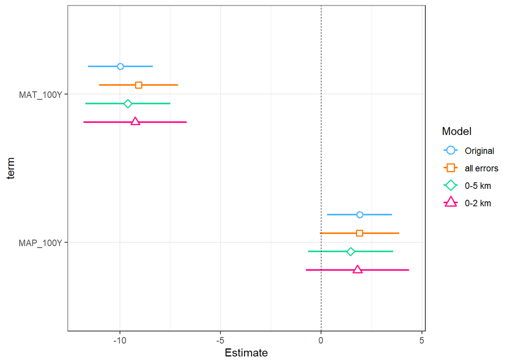

```r
##
#MAT & MAP
##
M100Y_lm1 <- lm(DOY ~ MAT_100Y + MAP_100Y, data = nemo_df2)

er_an0 <- lm(DOY ~ MAT_100Y + MAP_100Y, data = nemo_all_errors)
er_an1 <- lm(DOY ~ MAT_100Y + MAP_100Y, data = nemo_e0_5)
er_an2 <- lm(DOY ~ MAT_100Y + MAP_100Y, data = nemo_e2)

plot_summs(M100Y_lm1, er_an0, er_an1, er_an2, model.names = c("Original", "all errors", "0-5 km", "0-2 km"), scale = TRUE) + theme_bw()
```

```r
#scale = TRUE refits model to mean-center & standardize the predictors but not the response. Use 'center = TRUE' to only mean center variables
summary(M100Y_lm1) # N = 1677
```

```
##
## Call:
## lm(formula = DOY ~ MAT_100Y + MAP_100Y, data = nemo_df2)
##
## Residuals:
##     Min      1Q  Median      3Q     Max
## -92.411 -17.273  -1.012  16.576 118.874
##
## Coefficients:
##             Estimate Std. Error t value Pr(>|t|)
## (Intercept) 163.2975    15.2966  10.675   <2e-16 ***
## MAT_100Y     -5.5855     0.4598 -12.148   <2e-16 ***
## MAP_100Y      3.7348     1.6079   2.323   0.0203 *
## ---
## Signif. codes:  0 '***' 0.001 '**' 0.01 '*' 0.05 '.' 0.1 ' ' 1
##
## Residual standard error: 27.11 on 1674 degrees of freedom
## Multiple R-squared:  0.1461, Adjusted R-squared:  0.1451
## F-statistic: 143.2 on 2 and 1674 DF,  p-value: < 2.2e-16
```

```r
summary(er_an0)$r.squared # N = 1166
```

```
## [1] 0.1271034
```

```r
summary(er_an1)$r.squared # N = 1033
```

```
## [1] 0.1311241
```

```r
summary(er_an2)$r.squared # N = 743
```

```
## [1] 0.1204958
```

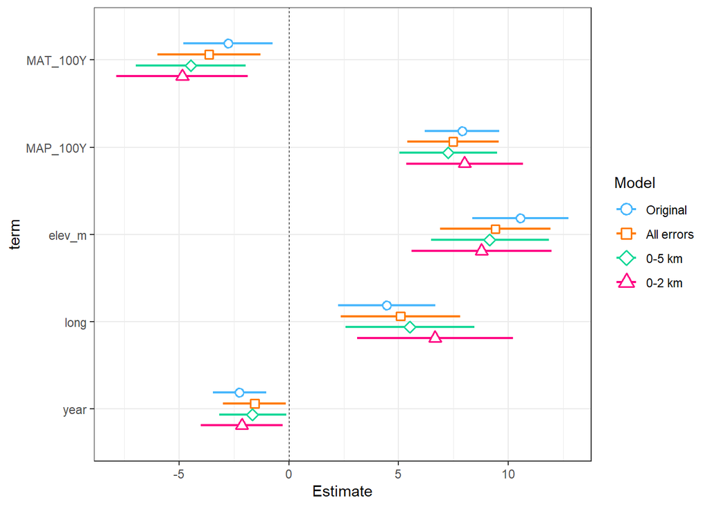

```r
#Including other covariates
M100Y_lm2 <- lm(DOY ~ MAT_100Y + MAP_100Y + elev_m + long + year, data = nemo_df2)

erc_an0 <- lm(DOY ~ MAT_100Y + MAP_100Y + elev_m + long + year, data = nemo_all_errors)
erc_an1 <- lm(DOY ~ MAT_100Y + MAP_100Y + elev_m + long + year, data = nemo_e0_5)
erc_an2 <- lm(DOY ~ MAT_100Y + MAP_100Y + elev_m + long + year, data = nemo_e2)

plot_summs(M100Y_lm2, erc_an0, erc_an1, erc_an2, model.names = c("Original", "All errors", "0-5 km", "0-2 km"), scale = TRUE) + theme_bw()
```

```r
summary(M100Y_lm2)
```

```
##
## Call:
## lm(formula = DOY ~ MAT_100Y + MAP_100Y + elev_m + long + year,
##     data = nemo_df2)
##
## Residuals:
##     Min      1Q  Median      3Q     Max
## -84.108 -14.867   0.053  14.836 147.637
##
## Coefficients:
##               Estimate Std. Error t value Pr(>|t|)
## (Intercept) 373.467511  71.233847   5.243 1.78e-07 ***
## MAT_100Y     -1.550047   0.582240  -2.662 0.007837 **
## MAP_100Y     15.450315   1.699227   9.093  < 2e-16 ***
## elev_m        0.021879   0.002319   9.434  < 2e-16 ***
## long          1.874374   0.471910   3.972 7.43e-05 ***
## year         -0.069089   0.019036  -3.629 0.000293 ***
## ---
## Signif. codes:  0 '***' 0.001 '**' 0.01 '*' 0.05 '.' 0.1 ' ' 1
##
## Residual standard error: 24.55 on 1671 degrees of freedom
## Multiple R-squared:  0.301,  Adjusted R-squared:  0.2989
## F-statistic: 143.9 on 5 and 1671 DF,  p-value: < 2.2e-16
```

```r
summary(erc_an0)$r.squared
```

```
## [1] 0.2926793
```

```r
summary(erc_an1)$r.squared
```

```
## [1] 0.3007084
```

```r
summary(erc_an2)$r.squared
```

```
## [1] 0.2976811
```

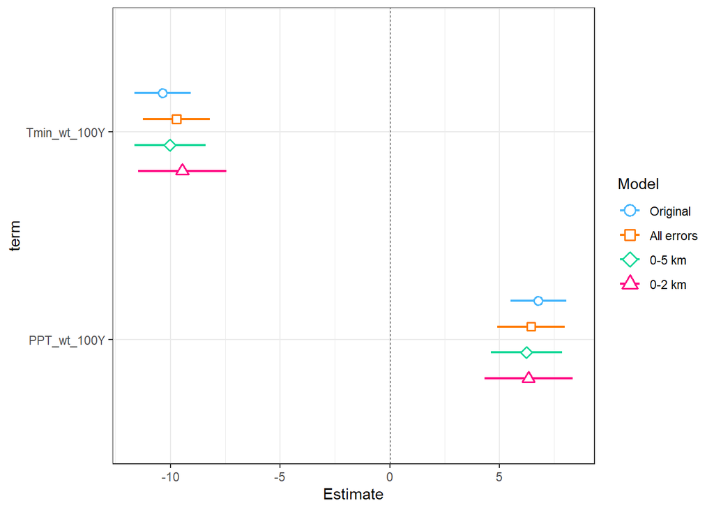

```r
##
#Winter
##

#Without covariates
Wt100Y_lm1 <- lm(DOY ~ Tmin_wt_100Y + PPT_wt_100Y, data = nemo_df2)

er_wt0 <- lm(DOY ~ Tmin_wt_100Y + PPT_wt_100Y, data = nemo_all_errors)
er_wt1 <- lm(DOY ~ Tmin_wt_100Y + PPT_wt_100Y, data = nemo_e0_5)
er_wt2 <- lm(DOY ~ Tmin_wt_100Y + PPT_wt_100Y, data = nemo_e2)

plot_summs(Wt100Y_lm1, er_wt0, er_wt1, er_wt2, model.names = c("Original", "All errors", "0-5 km", "0-2 km"), scale = TRUE) + theme_bw()
```

```r
summary(Wt100Y_lm1)
```

```
##
## Call:
## lm(formula = DOY ~ Tmin_wt_100Y + PPT_wt_100Y, data = nemo_df2)
##
## Residuals:
##     Min      1Q  Median      3Q     Max
## -83.497 -17.592  -1.428  17.248 137.692
##
## Coefficients:
##              Estimate Std. Error t value Pr(>|t|)
## (Intercept)   42.6650     7.1866   5.937 3.53e-09 ***
## Tmin_wt_100Y  -4.6510     0.2919 -15.934  < 2e-16 ***
## PPT_wt_100Y   12.9039     1.2386  10.418  < 2e-16 ***
## ---
## Signif. codes:  0 '***' 0.001 '**' 0.01 '*' 0.05 '.' 0.1 ' ' 1
##
## Residual standard error: 26.61 on 1674 degrees of freedom
## Multiple R-squared:  0.1773, Adjusted R-squared:  0.1763
## F-statistic: 180.4 on 2 and 1674 DF,  p-value: < 2.2e-16
```

```r
summary(er_wt0)$r.squared
```

```
## [1] 0.1618785
```

```r
summary(er_wt1)$r.squared
```

```
## [1] 0.1651836
```

```r
summary(er_wt2)$r.squared
```

```
## [1] 0.1448439
```

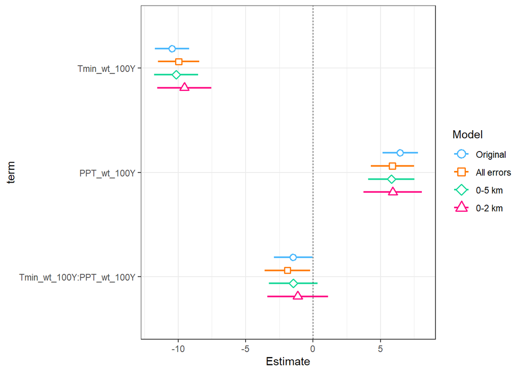

```r
#
#With Interactions (without other covariates)
Wt100Y_lm1i <- lm(DOY ~ Tmin_wt_100Y*PPT_wt_100Y, data = nemo_df2)

er_wt0i <- lm(DOY ~ Tmin_wt_100Y*PPT_wt_100Y, data = nemo_all_errors)
er_wt1i <- lm(DOY ~ Tmin_wt_100Y*PPT_wt_100Y, data = nemo_e0_5)
er_wt2i <- lm(DOY ~ Tmin_wt_100Y*PPT_wt_100Y, data = nemo_e2)

plot_summs(Wt100Y_lm1i, er_wt0i, er_wt1i, er_wt2i, model.names = c("Original", "All errors", "0-5 km", "0-2 km"), scale = TRUE) + theme_bw()
```

```r
summary(Wt100Y_lm1i)
```

```
##
## Call:
## lm(formula = DOY ~ Tmin_wt_100Y * PPT_wt_100Y, data = nemo_df2)
##
## Residuals:
##     Min      1Q  Median      3Q     Max
## -87.470 -17.591  -1.481  17.149 138.888
##
## Coefficients:
##                          Estimate Std. Error t value Pr(>|t|)
## (Intercept)               26.2726    10.8338   2.425   0.0154 *
## Tmin_wt_100Y               2.5305     3.5662   0.710   0.4781
## PPT_wt_100Y               15.7779     1.8854   8.369   <2e-16 ***
## Tmin_wt_100Y:PPT_wt_100Y  -1.2571     0.6222  -2.021   0.0435 *
## ---
## Signif. codes:  0 '***' 0.001 '**' 0.01 '*' 0.05 '.' 0.1 ' ' 1
##
## Residual standard error: 26.58 on 1673 degrees of freedom
## Multiple R-squared:  0.1793, Adjusted R-squared:  0.1778
## F-statistic: 121.9 on 3 and 1673 DF,  p-value: < 2.2e-16
```

```r
summary(er_wt0i)#$r.squared
```

```
##
## Call:
## lm(formula = DOY ~ Tmin_wt_100Y * PPT_wt_100Y, data = nemo_all_errors)
##
## Residuals:
##     Min      1Q  Median      3Q     Max
## -79.758 -17.528  -2.029  16.265 139.929
##
## Coefficients:
##                          Estimate Std. Error t value Pr(>|t|)
## (Intercept)               25.3292    12.7322   1.989   0.0469 *
## Tmin_wt_100Y               4.7494     4.1345   1.149   0.2509
## PPT_wt_100Y               15.6559     2.1979   7.123 1.85e-12 ***
## Tmin_wt_100Y:PPT_wt_100Y  -1.5860     0.7172  -2.211   0.0272 *
## ---
## Signif. codes:  0 '***' 0.001 '**' 0.01 '*' 0.05 '.' 0.1 ' ' 1
##
## Residual standard error: 26.53 on 1162 degrees of freedom
## Multiple R-squared:  0.1654, Adjusted R-squared:  0.1632
## F-statistic: 76.76 on 3 and 1162 DF,  p-value: < 2.2e-16
```

```r
summary(er_wt1i)#$r.squared
```

```
##
## Call:
## lm(formula = DOY ~ Tmin_wt_100Y * PPT_wt_100Y, data = nemo_e0_5)
##
## Residuals:
##     Min      1Q  Median      3Q     Max
## -80.047 -17.365  -2.277  16.423 139.615
##
## Coefficients:
##                          Estimate Std. Error t value Pr(>|t|)
## (Intercept)               31.1921    14.2258   2.193   0.0286 *
## Tmin_wt_100Y               2.7041     4.6244   0.585   0.5588
## PPT_wt_100Y               14.7773     2.4446   6.045 2.09e-09 ***
## Tmin_wt_100Y:PPT_wt_100Y  -1.2611     0.7984  -1.580   0.1145
## ---
## Signif. codes:  0 '***' 0.001 '**' 0.01 '*' 0.05 '.' 0.1 ' ' 1
##
## Residual standard error: 26.66 on 1029 degrees of freedom
## Multiple R-squared:  0.1672, Adjusted R-squared:  0.1648
## F-statistic: 68.87 on 3 and 1029 DF,  p-value: < 2.2e-16
```

```r
summary(er_wt2i)#$r.squared
```

```
##
## Call:
## lm(formula = DOY ~ Tmin_wt_100Y * PPT_wt_100Y, data = nemo_e2)
##
## Residuals:
##     Min      1Q  Median      3Q     Max
## -80.327 -17.695  -2.501  16.867 138.283
##
## Coefficients:
##                          Estimate Std. Error t value Pr(>|t|)
## (Intercept)               36.8858    16.7822   2.198   0.0283 *
## Tmin_wt_100Y               1.2653     5.8080   0.218   0.8276
## PPT_wt_100Y               13.8861     2.8770   4.827 1.69e-06 ***
## Tmin_wt_100Y:PPT_wt_100Y  -0.9836     1.0001  -0.983   0.3257
## ---
## Signif. codes:  0 '***' 0.001 '**' 0.01 '*' 0.05 '.' 0.1 ' ' 1
##
## Residual standard error: 27.82 on 739 degrees of freedom
## Multiple R-squared:  0.146,  Adjusted R-squared:  0.1425
## F-statistic:  42.1 on 3 and 739 DF,  p-value: < 2.2e-16
```

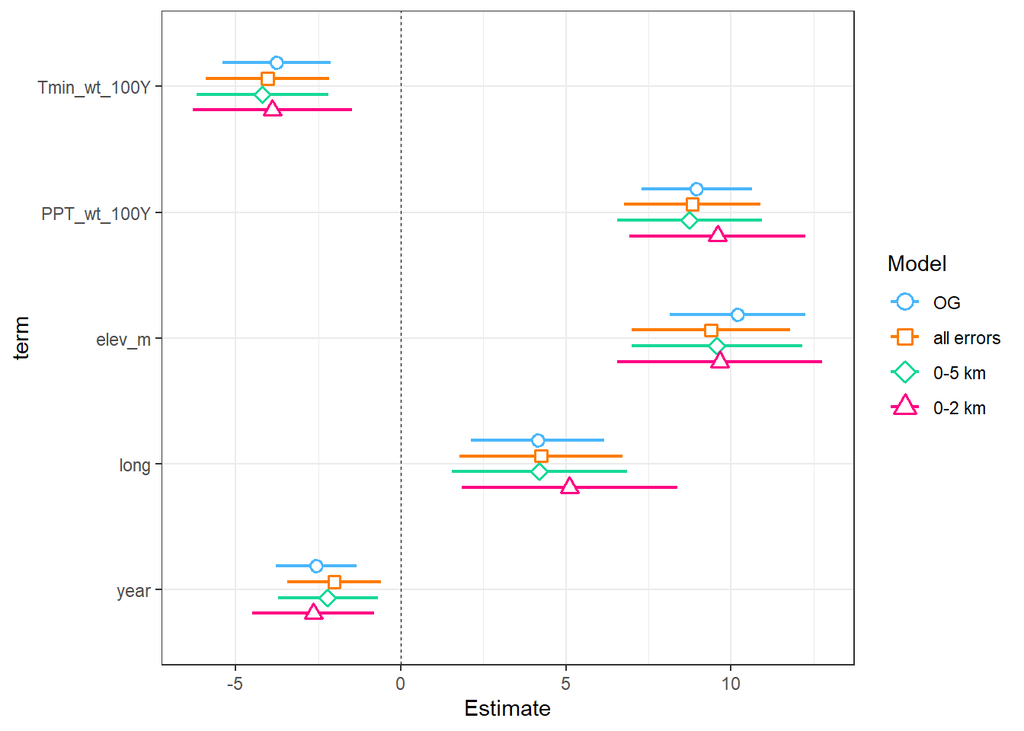

```r
#
#With Covariates
Wt100Y_lm2 <- lm(DOY ~ Tmin_wt_100Y + PPT_wt_100Y + elev_m + long + year, data = nemo_df2)

erc_wt0 <- lm(DOY ~ Tmin_wt_100Y + PPT_wt_100Y + elev_m + long + year, data = nemo_all_errors)
erc_wt1 <- lm(DOY ~ Tmin_wt_100Y + PPT_wt_100Y + elev_m + long + year, data = nemo_e0_5)
erc_wt2 <- lm(DOY ~ Tmin_wt_100Y + PPT_wt_100Y + elev_m + long + year, data = nemo_e2)

plot_summs(Wt100Y_lm2, erc_wt0, erc_wt1, erc_wt2, model.names = c("OG", "all errors", "0-5 km", "0-2 km"), scale = TRUE) + theme_bw()
```

```r
summary(Wt100Y_lm2)
```

```
##
## Call:
## lm(formula = DOY ~ Tmin_wt_100Y + PPT_wt_100Y + elev_m + long +
##     year, data = nemo_df2)
##
## Residuals:
##     Min      1Q  Median      3Q     Max
## -83.006 -14.892  -0.621  14.906 153.197
##
## Coefficients:
##                Estimate Std. Error t value Pr(>|t|)
## (Intercept)  359.097898  62.937628   5.706 1.37e-08 ***
## Tmin_wt_100Y  -1.689955   0.374198  -4.516 6.74e-06 ***
## PPT_wt_100Y   17.089181   1.622966  10.530  < 2e-16 ***
## elev_m         0.021161   0.002175   9.729  < 2e-16 ***
## long           1.743720   0.432253   4.034 5.73e-05 ***
## year          -0.078835   0.019091  -4.129 3.82e-05 ***
## ---
## Signif. codes:  0 '***' 0.001 '**' 0.01 '*' 0.05 '.' 0.1 ' ' 1
##
## Residual standard error: 24.53 on 1671 degrees of freedom
## Multiple R-squared:  0.3019, Adjusted R-squared:  0.2998
## F-statistic: 144.5 on 5 and 1671 DF,  p-value: < 2.2e-16
```

```r
summary(erc_wt0)$r.squared
```

```
## [1] 0.2928858
```

```r
summary(erc_wt1)$r.squared
```

```
## [1] 0.2987398
```

```r
summary(erc_wt2)$r.squared
```

```
## [1] 0.2928041
```

Including finer-scale error distances in ‘wt’ models with interactions increases the variance and, for 0-2 and 0-5 km, makes parameter estimates non-significant.

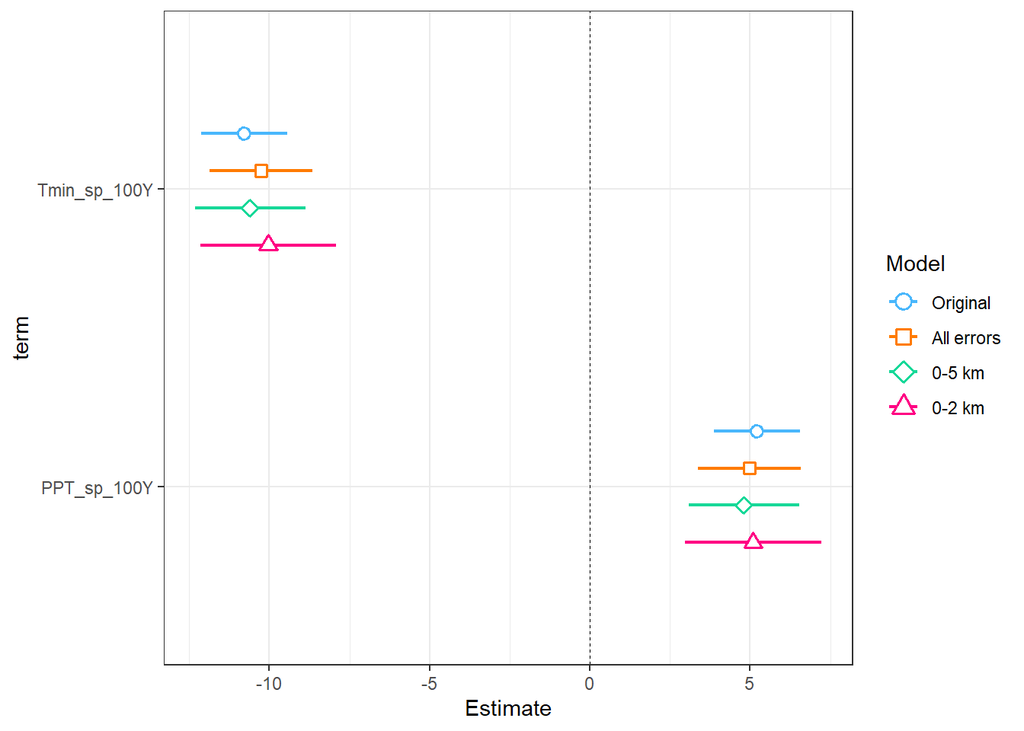

```r
##
#Spring
##

#Without covariates
Sp100Y_lm1 <- lm(DOY ~ Tmin_sp_100Y + PPT_sp_100Y, data = nemo_df2)

er_sp0 <- lm(DOY ~ Tmin_sp_100Y + PPT_sp_100Y, data = nemo_all_errors)
er_sp1 <- lm(DOY ~ Tmin_sp_100Y + PPT_sp_100Y, data = nemo_e0_5)
er_sp2 <- lm(DOY ~ Tmin_sp_100Y + PPT_sp_100Y, data = nemo_e2)

plot_summs(Sp100Y_lm1, er_sp0, er_sp1, er_sp2, model.names = c("Original", "All errors", "0-5 km", "0-2 km"), scale = TRUE) + theme_bw()
```

```r
summary(Sp100Y_lm1)
```

```
##
## Call:
## lm(formula = DOY ~ Tmin_sp_100Y + PPT_sp_100Y, data = nemo_df2)
##
## Residuals:
##     Min      1Q  Median      3Q     Max
## -85.438 -16.030  -1.082  15.910 135.771
##
## Coefficients:
##              Estimate Std. Error t value Pr(>|t|)
## (Intercept)   82.6268     7.9390  10.408  < 2e-16 ***
## Tmin_sp_100Y  -5.3977     0.3408 -15.836  < 2e-16 ***
## PPT_sp_100Y   10.6315     1.3884   7.657 3.19e-14 ***
## ---
## Signif. codes:  0 '***' 0.001 '**' 0.01 '*' 0.05 '.' 0.1 ' ' 1
##
## Residual standard error: 26.01 on 1674 degrees of freedom
## Multiple R-squared:  0.2137, Adjusted R-squared:  0.2128
## F-statistic: 227.5 on 2 and 1674 DF,  p-value: < 2.2e-16
```

```r
summary(er_sp0)$r.squared
```

```
## [1] 0.1998745
```

```r
summary(er_sp1)$r.squared
```

```
## [1] 0.2052333
```

```r
summary(er_sp2)$r.squared
```

```
## [1] 0.1834187
```

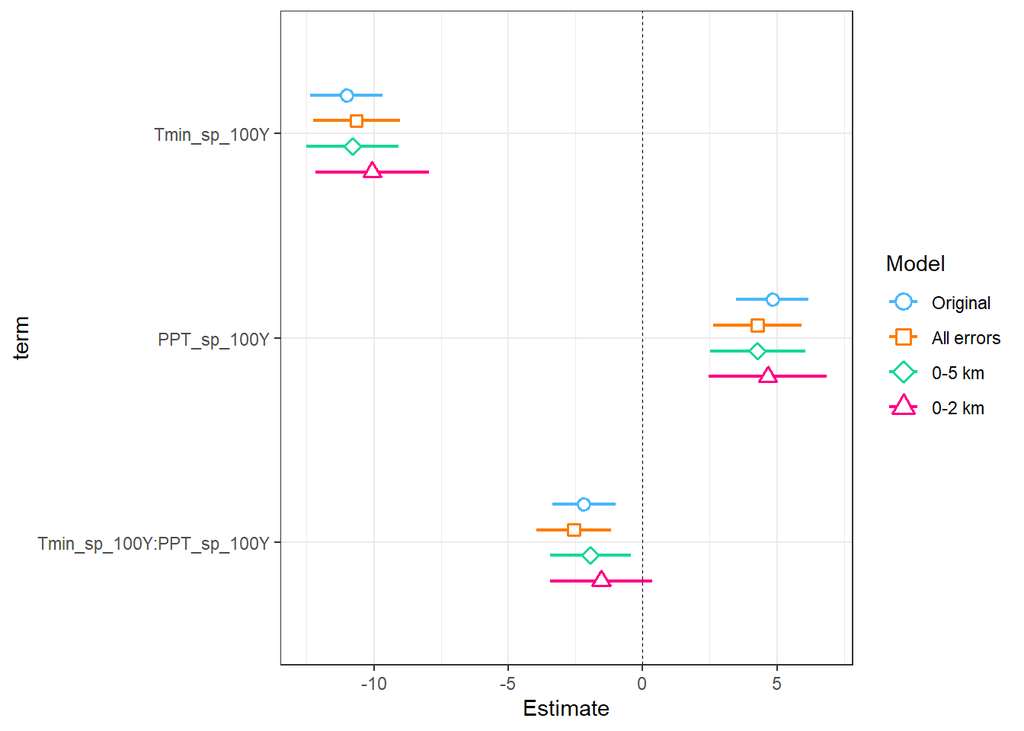

```r
#
#With interactions (without other covariates)
Sp100Y_lm1i <- lm(DOY ~ Tmin_sp_100Y*PPT_sp_100Y, data = nemo_df2)

er_sp0i <- lm(DOY ~ Tmin_sp_100Y*PPT_sp_100Y, data = nemo_all_errors)
er_sp1i <- lm(DOY ~ Tmin_sp_100Y*PPT_sp_100Y, data = nemo_e0_5)
er_sp2i <- lm(DOY ~ Tmin_sp_100Y*PPT_sp_100Y, data = nemo_e2)

plot_summs(Sp100Y_lm1i, er_sp0i, er_sp1i, er_sp2i, model.names = c("Original", "All errors", "0-5 km", "0-2 km"), scale = TRUE) + theme_bw()
```

```r
summary(Sp100Y_lm1i)
```

```
##
## Call:
## lm(formula = DOY ~ Tmin_sp_100Y * PPT_sp_100Y, data = nemo_df2)
##
## Residuals:
##    Min     1Q Median     3Q    Max
## -92.77 -16.07  -1.02  16.07 137.35
##
## Coefficients:
##                          Estimate Std. Error t value Pr(>|t|)
## (Intercept)               20.2243    18.8865   1.071 0.284399
## Tmin_sp_100Y               5.6785     3.0630   1.854 0.063927 .
## PPT_sp_100Y               23.0590     3.6850   6.258 4.96e-10 ***
## Tmin_sp_100Y:PPT_sp_100Y  -2.2324     0.6135  -3.639 0.000282 ***
## ---
## Signif. codes:  0 '***' 0.001 '**' 0.01 '*' 0.05 '.' 0.1 ' ' 1
##
## Residual standard error: 25.92 on 1673 degrees of freedom
## Multiple R-squared:  0.2199, Adjusted R-squared:  0.2185
## F-statistic: 157.2 on 3 and 1673 DF,  p-value: < 2.2e-16
```

```r
summary(er_sp0i)$r.squared
```

```
## [1] 0.2086506
```

```r
summary(er_sp1i)$r.squared
```

```
## [1] 0.2100489
```

```r
summary(er_sp2i)$r.squared
```

```
## [1] 0.1861911
```

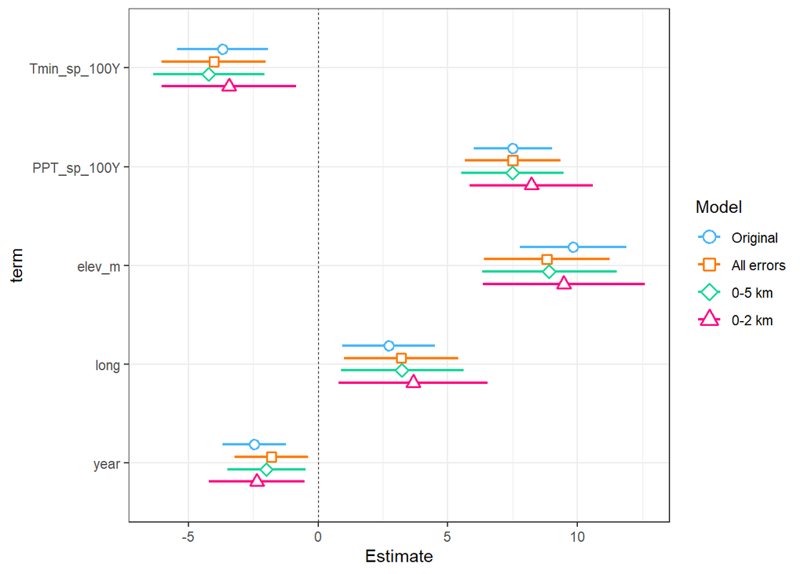

```r
#
#With Covariates - interaction ns and removed
Sp100Y_lm2 <- lm(DOY ~ Tmin_sp_100Y + PPT_sp_100Y + elev_m + long + year, data = nemo_df2)

erc_sp0 <- lm(DOY ~ Tmin_sp_100Y + PPT_sp_100Y + elev_m + long + year, data = nemo_all_errors)
erc_sp1 <- lm(DOY ~ Tmin_sp_100Y + PPT_sp_100Y + elev_m + long + year, data = nemo_e0_5)
erc_sp2 <- lm(DOY ~ Tmin_sp_100Y + PPT_sp_100Y + elev_m + long + year, data = nemo_e2)

plot_summs(Sp100Y_lm2, erc_sp0, erc_sp1, erc_sp2, model.names = c("Original", "All errors", "0-5 km", "0-2 km"), scale = TRUE) + theme_bw()
```

```r
summary(Sp100Y_lm2)
```

```
##
## Call:
## lm(formula = DOY ~ Tmin_sp_100Y + PPT_sp_100Y + elev_m + long +
##     year, data = nemo_df2)
##
## Residuals:
##     Min      1Q  Median      3Q     Max
## -82.539 -14.937  -0.524  15.097 150.818
##
## Coefficients:
##                Estimate Std. Error t value Pr(>|t|)
## (Intercept)  308.901885  60.762604   5.084 4.12e-07 ***
## Tmin_sp_100Y  -1.842038   0.446211  -4.128 3.84e-05 ***
## PPT_sp_100Y   15.322104   1.569475   9.763  < 2e-16 ***
## elev_m         0.020415   0.002172   9.401  < 2e-16 ***
## long           1.142965   0.382048   2.992  0.00282 **
## year          -0.075461   0.019047  -3.962 7.75e-05 ***
## ---
## Signif. codes:  0 '***' 0.001 '**' 0.01 '*' 0.05 '.' 0.1 ' ' 1
##
## Residual standard error: 24.44 on 1671 degrees of freedom
## Multiple R-squared:  0.3075, Adjusted R-squared:  0.3054
## F-statistic: 148.4 on 5 and 1671 DF,  p-value: < 2.2e-16
```

```r
summary(erc_sp0)#$r.squared
```

```
##
## Call:
## lm(formula = DOY ~ Tmin_sp_100Y + PPT_sp_100Y + elev_m + long +
##     year, data = nemo_all_errors)
##
## Residuals:
##     Min      1Q  Median      3Q     Max
## -81.696 -14.421  -0.892  14.729 150.711
##
## Coefficients:
##                Estimate Std. Error t value Pr(>|t|)
## (Intercept)  315.724647  70.357697   4.487 7.93e-06 ***
## Tmin_sp_100Y  -2.039023   0.519343  -3.926 9.14e-05 ***
## PPT_sp_100Y   15.142270   1.901091   7.965 3.92e-15 ***
## elev_m         0.018733   0.002629   7.125 1.82e-12 ***
## long           1.344800   0.471309   2.853   0.0044 **
## year          -0.065086   0.026041  -2.499   0.0126 *
## ---
## Signif. codes:  0 '***' 0.001 '**' 0.01 '*' 0.05 '.' 0.1 ' ' 1
##
## Residual standard error: 24.32 on 1160 degrees of freedom
## Multiple R-squared:  0.3002, Adjusted R-squared:  0.2971
## F-statistic:  99.5 on 5 and 1160 DF,  p-value: < 2.2e-16
```

```r
summary(erc_sp1)#$r.squared
```

```
##
## Call:
## lm(formula = DOY ~ Tmin_sp_100Y + PPT_sp_100Y + elev_m + long +
##     year, data = nemo_e0_5)
##
## Residuals:
##    Min     1Q Median     3Q    Max
## -82.05 -14.39  -1.07  14.50 150.86
##
## Coefficients:
##                Estimate Std. Error t value Pr(>|t|)
## (Intercept)  331.341914  75.393480   4.395 1.22e-05 ***
## Tmin_sp_100Y  -2.221526   0.576918  -3.851 0.000125 ***
## PPT_sp_100Y   15.397107   2.063089   7.463 1.80e-13 ***
## elev_m         0.019049   0.002829   6.735 2.73e-11 ***
## long           1.351816   0.502291   2.691 0.007233 **
## year          -0.072750   0.028020  -2.596 0.009557 **
## ---
## Signif. codes:  0 '***' 0.001 '**' 0.01 '*' 0.05 '.' 0.1 ' ' 1
##
## Residual standard error: 24.33 on 1027 degrees of freedom
## Multiple R-squared:  0.3076, Adjusted R-squared:  0.3043
## F-statistic: 91.26 on 5 and 1027 DF,  p-value: < 2.2e-16
```

```r
summary(erc_sp2)#$r.squared
```

```
##
## Call:
## lm(formula = DOY ~ Tmin_sp_100Y + PPT_sp_100Y + elev_m + long +
##     year, data = nemo_e2)
##
## Residuals:
##     Min      1Q  Median      3Q     Max
## -84.646 -15.199  -1.291  15.100 150.905
##
## Coefficients:
##                Estimate Std. Error t value Pr(>|t|)
## (Intercept)  374.067882  91.649216   4.082 4.96e-05 ***
## Tmin_sp_100Y  -1.865637   0.718246  -2.597  0.00958 **
## PPT_sp_100Y   16.486534   2.422514   6.806 2.09e-11 ***
## elev_m         0.020351   0.003412   5.965 3.79e-09 ***
## long           1.513154   0.605291   2.500  0.01264 *
## year          -0.088492   0.035184  -2.515  0.01211 *
## ---
## Signif. codes:  0 '***' 0.001 '**' 0.01 '*' 0.05 '.' 0.1 ' ' 1
##
## Residual standard error: 25.23 on 737 degrees of freedom
## Multiple R-squared:  0.2995, Adjusted R-squared:  0.2947
## F-statistic: 63.01 on 5 and 737 DF,  p-value: < 2.2e-16
```

##### In Summary

Filtering out larger error_bins led to no real improvements in model $R^2$s, though of the *subsets* the 0-5 group may have slightly better $R^2$s. Based on confidence intervals, there are no significant differences in parameter estimates between all observations and data including less uncertain coordinate estimates.

Using data from more precise error distances led to **increases in parameter estimate variation (SE)**, especially for 0-2 km.

Lack of improvements may be due to loss of meaningful variation from records with greater uncertainty. Also, looking only at records with any error distance, there is a reduction in $R^2$ values.

Using finer error distances may actually reduce variation and obscure meaningful variable interactions!!

In future models consider comparing all data with those with *errors from 0-5 km*?

## Error Distance as a covariate

*Note*: log-transformation of `error_dist_m` seems to improve normality, may be appropriate.

### DOY as response

`error_bin` level sizes:  
- <2 km = 743  
- 2-5 km = 290  
- 5-10 km = 91  
- 10-15 km = 24  
- >15 km = 18  
- NA = 511

`

```r
#hist(nemo_df2$error_dist_m)
#hist(log(nemo_df2$error_dist_m))
#Does error distance need to be transformed? Maybe....


M100Y_lm3a <- lm(DOY ~ MAT_100Y + MAP_100Y + error_dist_m, data = nemo_df2)
M100Y_lm3b <- lm(DOY ~ MAT_100Y + MAP_100Y + error_bin, data = nemo_df2)

summary(M100Y_lm3a)
```

```
##
## Call:
## lm(formula = DOY ~ MAT_100Y + MAP_100Y + error_dist_m, data = nemo_df2)
##
## Residuals:
##    Min     1Q Median     3Q    Max
## -82.47 -16.45  -1.49  16.13 121.83
##
## Coefficients:
##                Estimate Std. Error t value Pr(>|t|)
## (Intercept)   1.549e+02  1.875e+01   8.263 3.83e-16 ***
## MAT_100Y     -5.107e+00  5.658e-01  -9.026  < 2e-16 ***
## MAP_100Y      3.692e+00  1.928e+00   1.915   0.0558 .
## error_dist_m  5.284e-05  1.632e-04   0.324   0.7462
## ---
## Signif. codes:  0 '***' 0.001 '**' 0.01 '*' 0.05 '.' 0.1 ' ' 1
##
## Residual standard error: 27.13 on 1162 degrees of freedom
##   (511 observations deleted due to missingness)
## Multiple R-squared:  0.1272, Adjusted R-squared:  0.1249
## F-statistic: 56.44 on 3 and 1162 DF,  p-value: < 2.2e-16
```

```r
summary(M100Y_lm3b)
```

```
##
## Call:
## lm(formula = DOY ~ MAT_100Y + MAP_100Y + error_bin, data = nemo_df2)
##
## Residuals:
##     Min      1Q  Median      3Q     Max
## -84.333 -16.156  -1.522  16.323 120.008
##
## Coefficients:
##                   Estimate Std. Error t value Pr(>|t|)
## (Intercept)       159.7017    18.7003   8.540   <2e-16 ***
## MAT_100Y           -5.2205     0.5668  -9.210   <2e-16 ***
## MAP_100Y            3.4669     1.9188   1.807   0.0711 .
## error_bin2-5 km    -4.8020     1.8727  -2.564   0.0105 *
## error_bin5-10 km   -3.2616     3.0045  -1.086   0.2779
## error_bin>15 km     7.9144     6.4674   1.224   0.2213
## error_bin10-15 km  -9.5102     5.6362  -1.687   0.0918 .
## ---
## Signif. codes:  0 '***' 0.001 '**' 0.01 '*' 0.05 '.' 0.1 ' ' 1
##
## Residual standard error: 27.04 on 1159 degrees of freedom
##   (511 observations deleted due to missingness)
## Multiple R-squared:  0.1355, Adjusted R-squared:  0.131
## F-statistic: 30.27 on 6 and 1159 DF,  p-value: < 2.2e-16
```

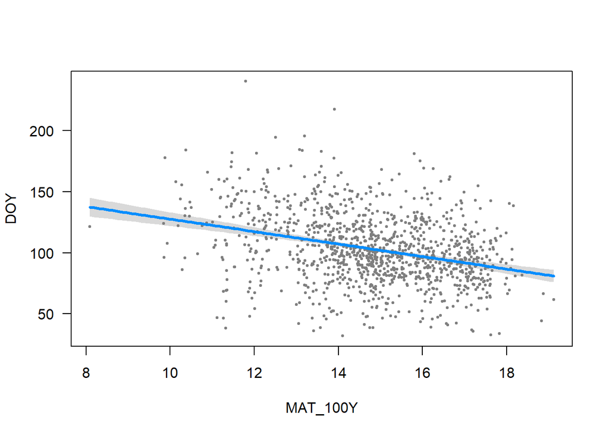

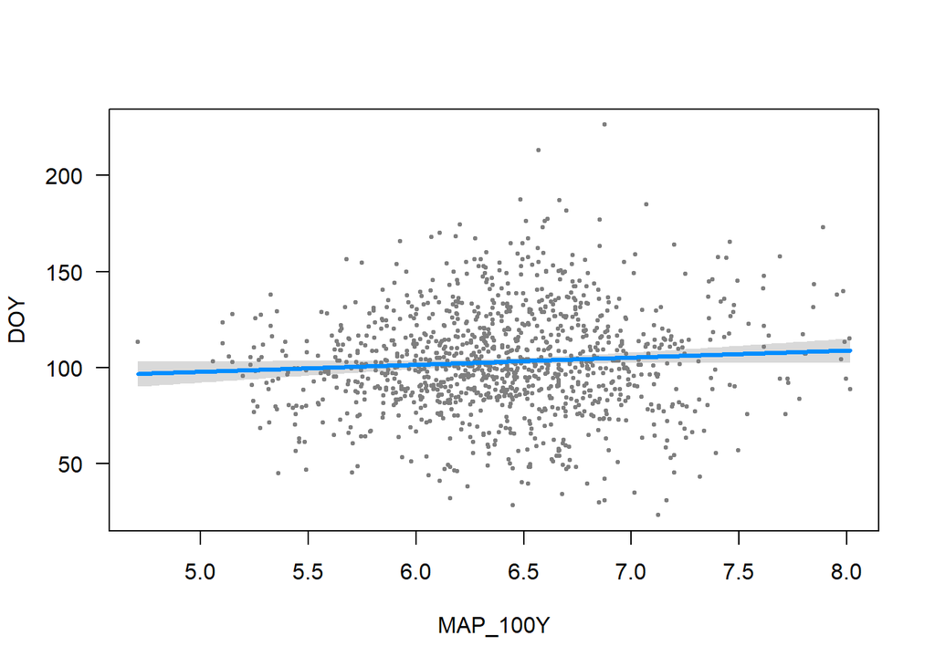

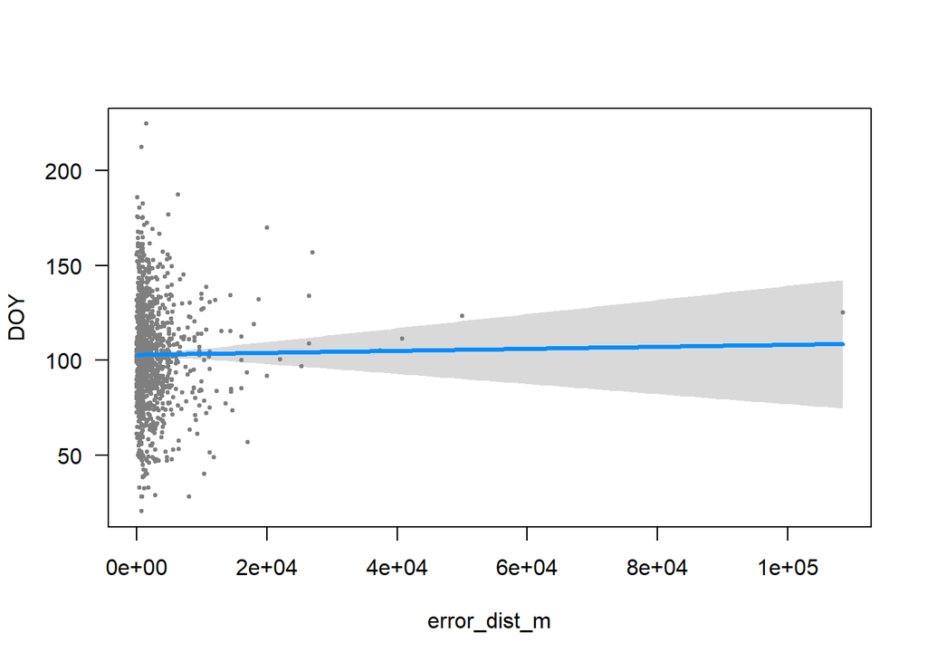

```r
visreg(M100Y_lm3a)
```

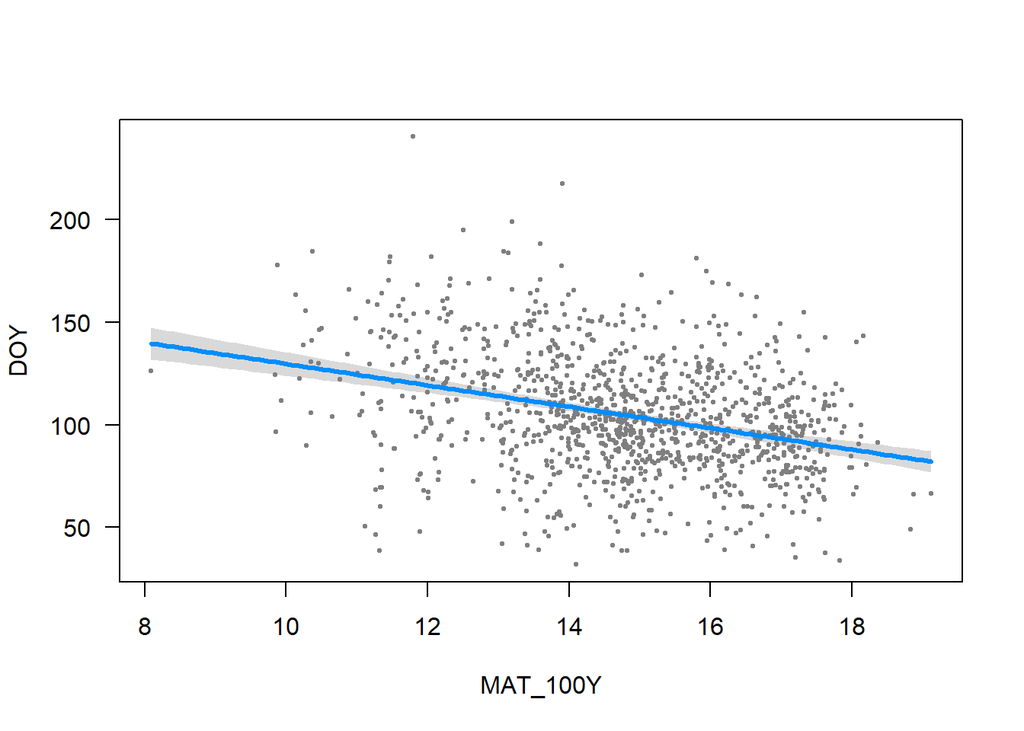

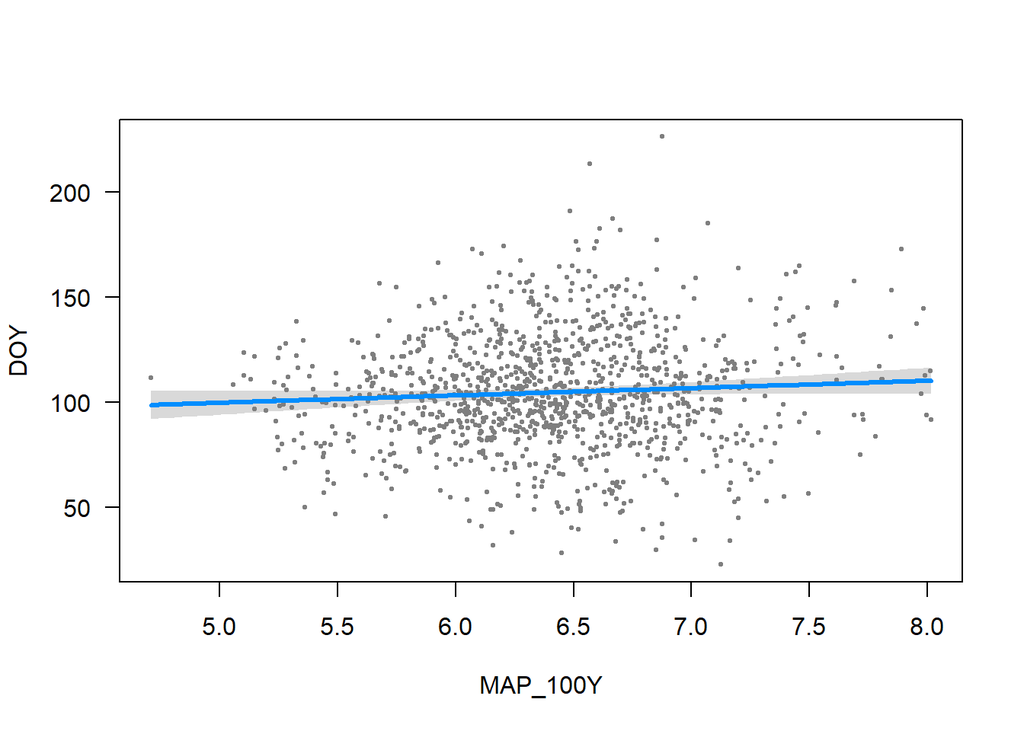

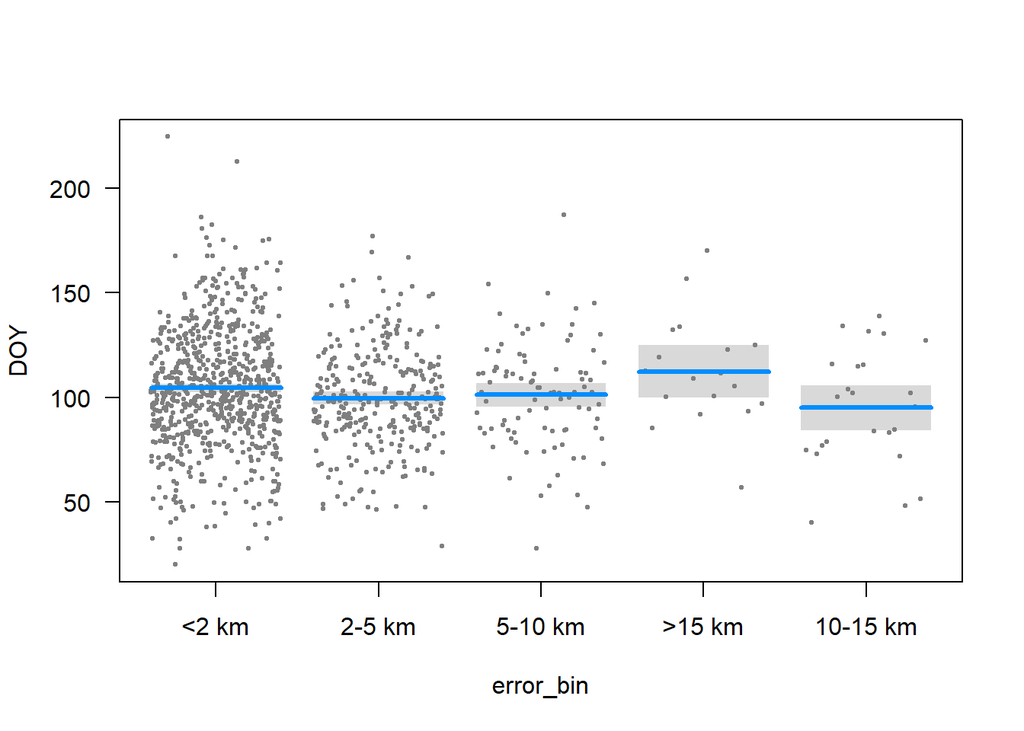

```r
visreg(M100Y_lm3b)
```

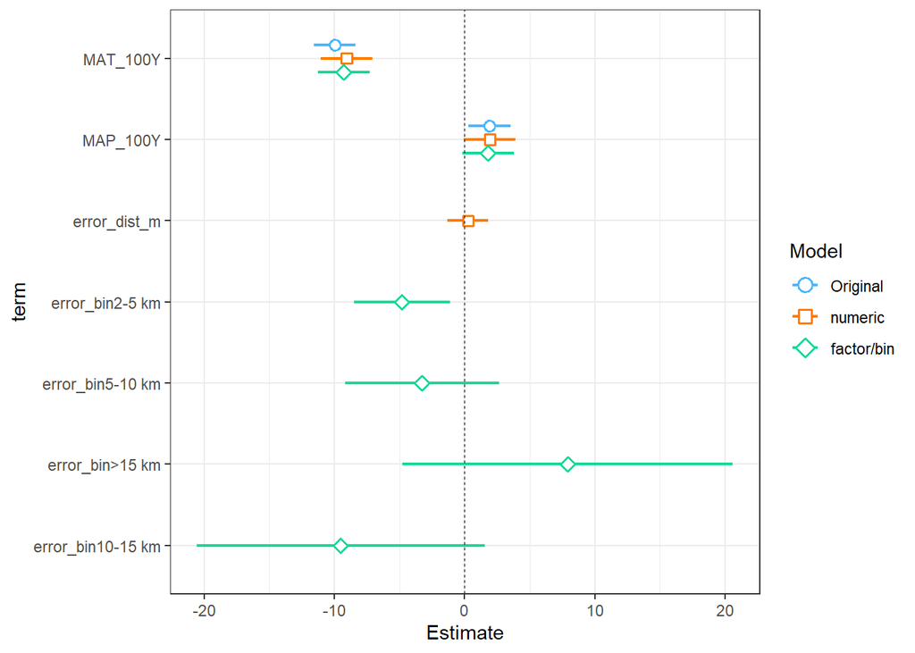

```r
plot_summs(M100Y_lm1, M100Y_lm3a, M100Y_lm3b, model.names = c("Original", "numeric", "factor/bin"), scale = TRUE) + theme_bw()
```

```r
#Other predictors included
M100Y_lm4a <- lm(DOY ~ MAT_100Y + MAP_100Y + elev_m + long + year + error_dist_m, data = nemo_df2)
M100Y_lm4b <- lm(DOY ~ MAT_100Y + MAP_100Y + elev_m + long + year + error_bin, data = nemo_df2)

summary(M100Y_lm4a)
```

```
##
## Call:
## lm(formula = DOY ~ MAT_100Y + MAP_100Y + elev_m + long + year +
##     error_dist_m, data = nemo_df2)
##
## Residuals:
##     Min      1Q  Median      3Q     Max
## -82.969 -14.503  -0.335  14.915 146.454
##
## Coefficients:
##                Estimate Std. Error t value Pr(>|t|)
## (Intercept)   3.930e+02  8.197e+01   4.795 1.84e-06 ***
## MAT_100Y     -2.049e+00  6.727e-01  -3.046 0.002370 **
## MAP_100Y      1.435e+01  2.034e+00   7.056 2.95e-12 ***
## elev_m        1.994e-02  2.731e-03   7.303 5.23e-13 ***
## long          2.137e+00  5.809e-01   3.679 0.000245 ***
## year         -5.515e-02  2.686e-02  -2.053 0.040255 *
## error_dist_m  2.990e-05  1.504e-04   0.199 0.842447
## ---
## Signif. codes:  0 '***' 0.001 '**' 0.01 '*' 0.05 '.' 0.1 ' ' 1
##
## Residual standard error: 24.46 on 1159 degrees of freedom
##   (511 observations deleted due to missingness)
## Multiple R-squared:  0.2927, Adjusted R-squared:  0.289
## F-statistic: 79.94 on 6 and 1159 DF,  p-value: < 2.2e-16
```

```r
summary(M100Y_lm4b)
```

```
##
## Call:
## lm(formula = DOY ~ MAT_100Y + MAP_100Y + elev_m + long + year +
##     error_bin, data = nemo_df2)
##
## Residuals:
##     Min      1Q  Median      3Q     Max
## -83.813 -14.430  -0.272  14.685 144.966
##
## Coefficients:
##                     Estimate Std. Error t value Pr(>|t|)
## (Intercept)       436.997593  83.181840   5.254 1.78e-07 ***
## MAT_100Y           -2.207233   0.675419  -3.268 0.001115 **
## MAP_100Y           14.084992   2.026027   6.952 6.01e-12 ***
## elev_m              0.019519   0.002731   7.147 1.57e-12 ***
## long                2.142562   0.580038   3.694 0.000231 ***
## year               -0.074420   0.027779  -2.679 0.007488 **
## error_bin2-5 km    -4.184404   1.759393  -2.378 0.017553 *
## error_bin5-10 km   -2.347072   2.785853  -0.842 0.399684
## error_bin>15 km     5.051019   5.889901   0.858 0.391306
## error_bin10-15 km  -7.685146   5.118190  -1.502 0.133490
## ---
## Signif. codes:  0 '***' 0.001 '**' 0.01 '*' 0.05 '.' 0.1 ' ' 1
##
## Residual standard error: 24.4 on 1156 degrees of freedom
##   (511 observations deleted due to missingness)
## Multiple R-squared:  0.2979, Adjusted R-squared:  0.2924
## F-statistic:  54.5 on 9 and 1156 DF,  p-value: < 2.2e-16
```

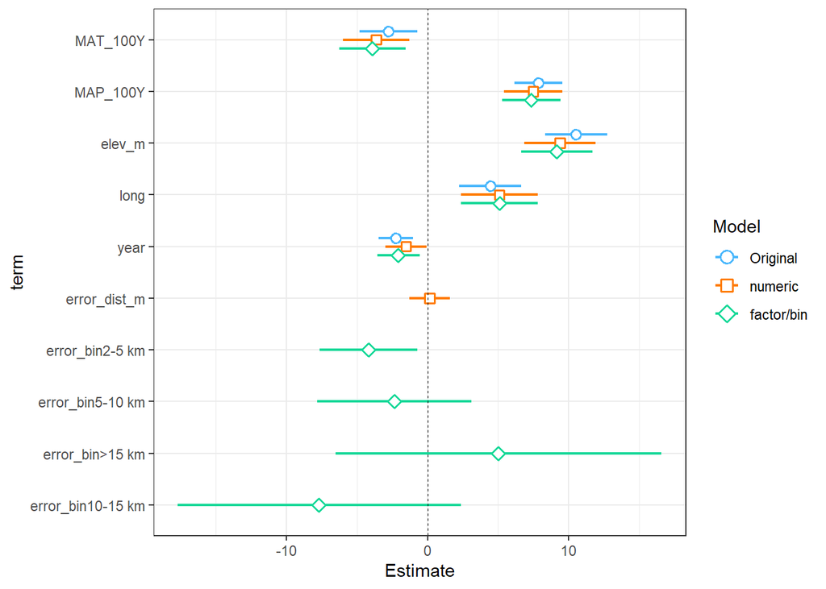

```r
plot_summs(M100Y_lm2, M100Y_lm4a, M100Y_lm4b, model.names = c("Original", "numeric", "factor/bin"), scale = TRUE) + theme_bw()
```

```r
#AIC Comparison - MAT/MAP
AIC(M100Y_lm1, M100Y_lm3a, M100Y_lm3b, M100Y_lm2, M100Y_lm4a, M100Y_lm4b)
```

```
##            df      AIC
## M100Y_lm1   4 15831.86
## M100Y_lm3a  5 11012.28
## M100Y_lm3b  8 11007.13
## M100Y_lm2   7 15502.15
## M100Y_lm4a  8 10773.10
## M100Y_lm4b 11 10770.52
```

```r
Wt100Y_lm3a <- lm(DOY ~ Tmin_wt_100Y + PPT_wt_100Y + error_dist_m, data = nemo_df2)
Wt100Y_lm3b <- lm(DOY ~ Tmin_wt_100Y + PPT_wt_100Y + error_bin, data = nemo_df2)

summary(Wt100Y_lm3a)
```

```
##
## Call:
## lm(formula = DOY ~ Tmin_wt_100Y + PPT_wt_100Y + error_dist_m,
##     data = nemo_df2)
##
## Residuals:
##     Min      1Q  Median      3Q     Max
## -78.191 -17.298  -2.105  16.519 138.563
##
## Coefficients:
##                Estimate Std. Error t value Pr(>|t|)
## (Intercept)   4.616e+01  8.659e+00   5.331 1.17e-07 ***
## Tmin_wt_100Y -4.360e+00  3.496e-01 -12.473  < 2e-16 ***
## PPT_wt_100Y   1.201e+01  1.462e+00   8.216 5.56e-16 ***
## error_dist_m  1.048e-05  1.602e-04   0.065    0.948
## ---
## Signif. codes:  0 '***' 0.001 '**' 0.01 '*' 0.05 '.' 0.1 ' ' 1
##
## Residual standard error: 26.59 on 1162 degrees of freedom
##   (511 observations deleted due to missingness)
## Multiple R-squared:  0.1619, Adjusted R-squared:  0.1597
## F-statistic: 74.81 on 3 and 1162 DF,  p-value: < 2.2e-16
```

```r
summary(Wt100Y_lm3b)
```

```
##
## Call:
## lm(formula = DOY ~ Tmin_wt_100Y + PPT_wt_100Y + error_bin, data = nemo_df2)
##
## Residuals:
##     Min      1Q  Median      3Q     Max
## -79.569 -16.984  -2.117  16.782 137.231
##
## Coefficients:
##                   Estimate Std. Error t value Pr(>|t|)
## (Intercept)        47.3622     8.5830   5.518 4.22e-08 ***
## Tmin_wt_100Y       -4.3719     0.3499 -12.496  < 2e-16 ***
## PPT_wt_100Y        12.0437     1.4536   8.286 3.22e-16 ***
## error_bin2-5 km    -3.6689     1.8382  -1.996   0.0462 *
## error_bin5-10 km   -4.0113     2.9460  -1.362   0.1736
## error_bin>15 km     6.3169     6.3463   0.995   0.3198
## error_bin10-15 km  -9.3153     5.5188  -1.688   0.0917 .
## ---
## Signif. codes:  0 '***' 0.001 '**' 0.01 '*' 0.05 '.' 0.1 ' ' 1
##
## Residual standard error: 26.52 on 1159 degrees of freedom
##   (511 observations deleted due to missingness)
## Multiple R-squared:  0.1681, Adjusted R-squared:  0.1638
## F-statistic: 39.04 on 6 and 1159 DF,  p-value: < 2.2e-16
```

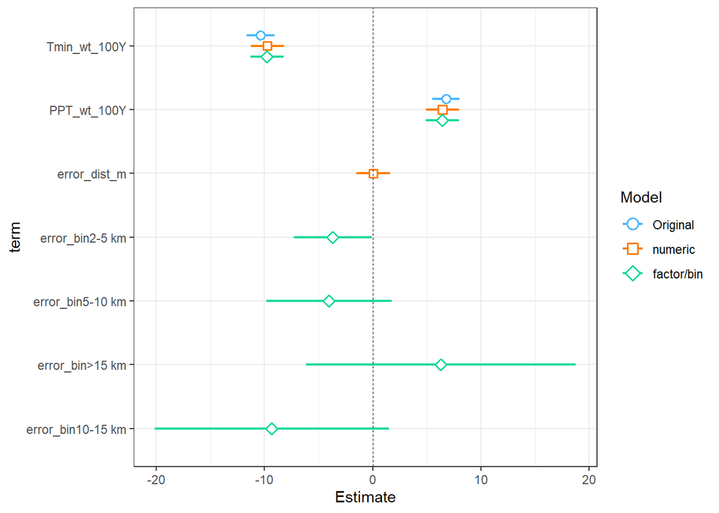

```r
plot_summs(Wt100Y_lm1, Wt100Y_lm3a, Wt100Y_lm3b, model.names = c("Original", "numeric", "factor/bin"), scale = TRUE) + theme_bw()
```

```r
#With Interactions
#No interactions with error dist/bin
Wt100Y_lm3ai <- lm(DOY ~ Tmin_wt_100Y*PPT_wt_100Y + error_dist_m, data = nemo_df2)
Wt100Y_lm3bi <- lm(DOY ~ Tmin_wt_100Y*PPT_wt_100Y + error_bin, data = nemo_df2)

summary(Wt100Y_lm3ai)
```

```
##
## Call:
## lm(formula = DOY ~ Tmin_wt_100Y * PPT_wt_100Y + error_dist_m,
##     data = nemo_df2)
##
## Residuals:
##     Min      1Q  Median      3Q     Max
## -79.752 -17.528  -2.067  16.211 139.932
##
## Coefficients:
##                            Estimate Std. Error t value Pr(>|t|)
## (Intercept)               2.528e+01  1.281e+01   1.974   0.0486 *
## Tmin_wt_100Y              4.748e+00  4.136e+00   1.148   0.2513
## PPT_wt_100Y               1.566e+01  2.204e+00   7.106 2.07e-12 ***
## error_dist_m              6.141e-06  1.600e-04   0.038   0.9694
## Tmin_wt_100Y:PPT_wt_100Y -1.586e+00  7.175e-01  -2.210   0.0273 *
## ---
## Signif. codes:  0 '***' 0.001 '**' 0.01 '*' 0.05 '.' 0.1 ' ' 1
##
## Residual standard error: 26.54 on 1161 degrees of freedom
##   (511 observations deleted due to missingness)
## Multiple R-squared:  0.1654, Adjusted R-squared:  0.1625
## F-statistic: 57.52 on 4 and 1161 DF,  p-value: < 2.2e-16
```

```r
summary(Wt100Y_lm3bi)
```

```
##
## Call:
## lm(formula = DOY ~ Tmin_wt_100Y * PPT_wt_100Y + error_bin, data = nemo_df2)
##
## Residuals:
##     Min      1Q  Median      3Q     Max
## -81.080 -17.149  -2.011  16.231 138.577
##
## Coefficients:
##                          Estimate Std. Error t value Pr(>|t|)
## (Intercept)                26.892     12.758   2.108   0.0353 *
## Tmin_wt_100Y                4.538      4.129   1.099   0.2719
## PPT_wt_100Y                15.617      2.197   7.108 2.06e-12 ***
## error_bin2-5 km            -3.663      1.835  -1.996   0.0462 *
## error_bin5-10 km           -4.000      2.941  -1.360   0.1741
## error_bin>15 km             6.214      6.336   0.981   0.3269
## error_bin10-15 km          -9.021      5.512  -1.637   0.1020
## Tmin_wt_100Y:PPT_wt_100Y   -1.551      0.716  -2.166   0.0305 *
## ---
## Signif. codes:  0 '***' 0.001 '**' 0.01 '*' 0.05 '.' 0.1 ' ' 1
##
## Residual standard error: 26.48 on 1158 degrees of freedom
##   (511 observations deleted due to missingness)
## Multiple R-squared:  0.1715, Adjusted R-squared:  0.1665
## F-statistic: 34.24 on 7 and 1158 DF,  p-value: < 2.2e-16
```

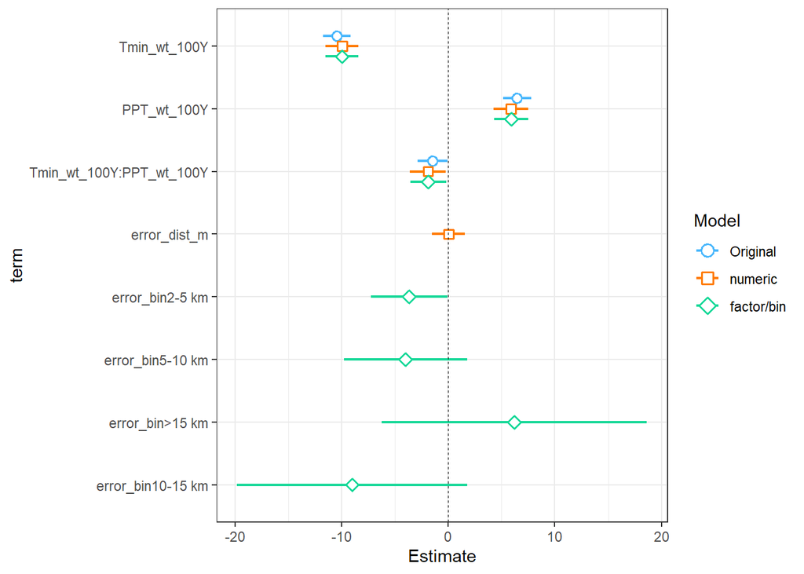

```r
plot_summs(Wt100Y_lm1i, Wt100Y_lm3ai, Wt100Y_lm3bi, model.names = c("Original", "numeric", "factor/bin"), scale = TRUE) + theme_bw()
```

```r
#With other predictors
Wt100Y_lm4a <- lm(DOY ~ Tmin_wt_100Y + PPT_wt_100Y + elev_m + long + year + error_dist_m, data = nemo_df2)
Wt100Y_lm4b <- lm(DOY ~ Tmin_wt_100Y + PPT_wt_100Y + elev_m + long + year + error_bin, data = nemo_df2)

summary(Wt100Y_lm4a)
```

```
##
## Call:
## lm(formula = DOY ~ Tmin_wt_100Y + PPT_wt_100Y + elev_m + long +
##     year + error_dist_m, data = nemo_df2)
##
## Residuals:
##     Min      1Q  Median      3Q     Max
## -81.871 -14.825  -1.143  14.603 153.176
##
## Coefficients:
##                Estimate Std. Error t value Pr(>|t|)
## (Intercept)   3.557e+02  7.377e+01   4.822 1.61e-06 ***
## Tmin_wt_100Y -1.808e+00  4.273e-01  -4.231 2.51e-05 ***
## PPT_wt_100Y   1.647e+01  1.967e+00   8.373  < 2e-16 ***
## elev_m        1.995e-02  2.609e-03   7.647 4.32e-14 ***
## long          1.784e+00  5.284e-01   3.376 0.000759 ***
## year         -7.237e-02  2.672e-02  -2.709 0.006856 **
## error_dist_m  5.477e-06  1.509e-04   0.036 0.971050
## ---
## Signif. codes:  0 '***' 0.001 '**' 0.01 '*' 0.05 '.' 0.1 ' ' 1
##
## Residual standard error: 24.45 on 1159 degrees of freedom
##   (511 observations deleted due to missingness)
## Multiple R-squared:  0.2929, Adjusted R-squared:  0.2892
## F-statistic: 80.01 on 6 and 1159 DF,  p-value: < 2.2e-16
```

```r
summary(Wt100Y_lm4b)
```

```
##
## Call:
## lm(formula = DOY ~ Tmin_wt_100Y + PPT_wt_100Y + elev_m + long +
##     year + error_bin, data = nemo_df2)
##
## Residuals:
##     Min      1Q  Median      3Q     Max
## -82.763 -14.857  -0.565  15.057 152.053
##
## Coefficients:
##                     Estimate Std. Error t value Pr(>|t|)
## (Intercept)       395.330548  75.066720   5.266 1.66e-07 ***
## Tmin_wt_100Y       -1.878339   0.428447  -4.384 1.27e-05 ***
## PPT_wt_100Y        16.437614   1.958956   8.391  < 2e-16 ***
## elev_m              0.019623   0.002613   7.509 1.19e-13 ***
## long                1.756566   0.527685   3.329 0.000900 ***
## year               -0.093318   0.027667  -3.373 0.000768 ***
## error_bin2-5 km    -4.192338   1.758299  -2.384 0.017272 *
## error_bin5-10 km   -3.191238   2.793212  -1.142 0.253484
## error_bin>15 km     4.104812   5.884180   0.698 0.485567
## error_bin10-15 km  -7.685009   5.116370  -1.502 0.133359
## ---
## Signif. codes:  0 '***' 0.001 '**' 0.01 '*' 0.05 '.' 0.1 ' ' 1
##
## Residual standard error: 24.39 on 1156 degrees of freedom
##   (511 observations deleted due to missingness)
## Multiple R-squared:  0.2981, Adjusted R-squared:  0.2926
## F-statistic: 54.55 on 9 and 1156 DF,  p-value: < 2.2e-16
```

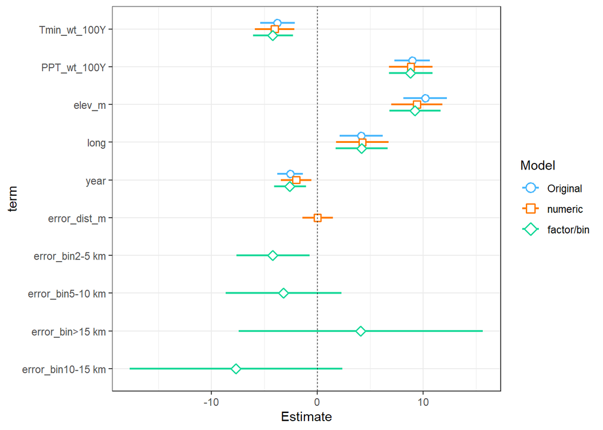

```r
plot_summs(Wt100Y_lm2, Wt100Y_lm4a, Wt100Y_lm4b, model.names = c("Original", "numeric", "factor/bin"), scale = TRUE) + theme_bw()
```

```r
#AIC Comparison - Winter
AIC(Wt100Y_lm1, Wt100Y_lm3a, Wt100Y_lm3b, Wt100Y_lm1i, Wt100Y_lm3ai, Wt100Y_lm3bi, Wt100Y_lm2, Wt100Y_lm4a, Wt100Y_lm4b)
```

```
##              df      AIC
## Wt100Y_lm1    4 15769.43
## Wt100Y_lm3a   5 10964.98
## Wt100Y_lm3b   8 10962.24
## Wt100Y_lm1i   5 15767.34
## Wt100Y_lm3ai  6 10962.09
## Wt100Y_lm3bi  9 10959.53
## Wt100Y_lm2    7 15500.17
## Wt100Y_lm4a   8 10772.80
## Wt100Y_lm4b  11 10770.20
```

```r
####
#Spring
####
Sp100Y_lm3a <- lm(DOY ~ Tmin_sp_100Y + PPT_sp_100Y + error_dist_m, data = nemo_df2)
Sp100Y_lm3b <- lm(DOY ~ Tmin_sp_100Y + PPT_sp_100Y + error_bin, data = nemo_df2)

summary(Sp100Y_lm3a)
```

```
##
## Call:
## lm(formula = DOY ~ Tmin_sp_100Y + PPT_sp_100Y + error_dist_m,
##     data = nemo_df2)
##
## Residuals:
##     Min      1Q  Median      3Q     Max
## -80.034 -15.785  -1.816  16.234 136.591
##
## Coefficients:
##                Estimate Std. Error t value Pr(>|t|)
## (Intercept)   8.305e+01  9.738e+00   8.529  < 2e-16 ***
## Tmin_sp_100Y -5.196e+00  4.165e-01 -12.477  < 2e-16 ***
## PPT_sp_100Y   1.014e+01  1.666e+00   6.090 1.53e-09 ***
## error_dist_m  8.533e-05  1.563e-04   0.546    0.585
## ---
## Signif. codes:  0 '***' 0.001 '**' 0.01 '*' 0.05 '.' 0.1 ' ' 1
##
## Residual standard error: 25.97 on 1162 degrees of freedom
##   (511 observations deleted due to missingness)
## Multiple R-squared:  0.2001, Adjusted R-squared:  0.198
## F-statistic: 96.88 on 3 and 1162 DF,  p-value: < 2.2e-16
```

```r
summary(Sp100Y_lm3b)
```

```
##
## Call:
## lm(formula = DOY ~ Tmin_sp_100Y + PPT_sp_100Y + error_bin, data = nemo_df2)
##
## Residuals:
##     Min      1Q  Median      3Q     Max
## -81.324 -15.826  -1.565  16.244 135.405
##
## Coefficients:
##                   Estimate Std. Error t value Pr(>|t|)
## (Intercept)        84.7793     9.6566   8.779  < 2e-16 ***
## Tmin_sp_100Y       -5.2265     0.4175 -12.517  < 2e-16 ***
## PPT_sp_100Y        10.1037     1.6552   6.104 1.41e-09 ***
## error_bin2-5 km    -3.1960     1.7969  -1.779   0.0756 .
## error_bin5-10 km   -3.2107     2.8785  -1.115   0.2649
## error_bin>15 km     8.8681     6.1940   1.432   0.1525
## error_bin10-15 km -10.0035     5.3903  -1.856   0.0637 .
## ---
## Signif. codes:  0 '***' 0.001 '**' 0.01 '*' 0.05 '.' 0.1 ' ' 1
##
## Residual standard error: 25.91 on 1159 degrees of freedom
##   (511 observations deleted due to missingness)
## Multiple R-squared:  0.2063, Adjusted R-squared:  0.2022
## F-statistic:  50.2 on 6 and 1159 DF,  p-value: < 2.2e-16
```

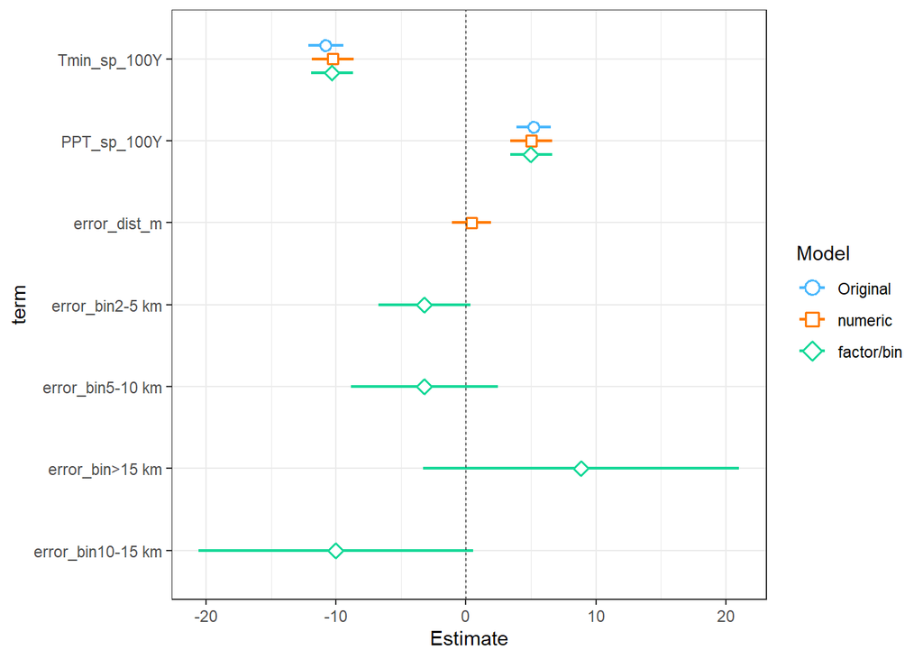

```r
plot_summs(Sp100Y_lm1, Sp100Y_lm3a, Sp100Y_lm3b, model.names = c("Original", "numeric", "factor/bin"), scale = TRUE) + theme_bw()
```

```r
#With Interactions
Sp100Y_lm3ai <- lm(DOY ~ Tmin_sp_100Y*PPT_sp_100Y + error_dist_m, data = nemo_df2)
Sp100Y_lm3bi <- lm(DOY ~ Tmin_sp_100Y*PPT_sp_100Y + error_bin, data = nemo_df2)

summary(Sp100Y_lm3ai)
```

```
##
## Call:
## lm(formula = DOY ~ Tmin_sp_100Y * PPT_sp_100Y + error_dist_m,
##     data = nemo_df2)
##
## Residuals:
##     Min      1Q  Median      3Q     Max
## -82.226 -15.989  -1.296  16.016 138.379
##
## Coefficients:
##                            Estimate Std. Error t value Pr(>|t|)
## (Intercept)               1.095e+01  2.252e+01   0.486 0.626876
## Tmin_sp_100Y              7.828e+00  3.696e+00   2.118 0.034385 *
## PPT_sp_100Y               2.450e+01  4.374e+00   5.601 2.66e-08 ***
## error_dist_m              7.064e-06  1.570e-04   0.045 0.964127
## Tmin_sp_100Y:PPT_sp_100Y -2.616e+00  7.376e-01  -3.546 0.000406 ***
## ---
## Signif. codes:  0 '***' 0.001 '**' 0.01 '*' 0.05 '.' 0.1 ' ' 1
##
## Residual standard error: 25.85 on 1161 degrees of freedom
##   (511 observations deleted due to missingness)
## Multiple R-squared:  0.2087, Adjusted R-squared:  0.2059
## F-statistic: 76.53 on 4 and 1161 DF,  p-value: < 2.2e-16
```

```r
summary(Sp100Y_lm3bi)
```

```
##
## Call:
## lm(formula = DOY ~ Tmin_sp_100Y * PPT_sp_100Y + error_bin, data = nemo_df2)
##
## Residuals:
##     Min      1Q  Median      3Q     Max
## -83.440 -16.146  -1.296  16.095 137.193
##
## Coefficients:
##                          Estimate Std. Error t value Pr(>|t|)
## (Intercept)                13.003     22.431   0.580 0.562238
## Tmin_sp_100Y                7.650      3.660   2.090 0.036811 *
## PPT_sp_100Y                24.353      4.348   5.601 2.66e-08 ***
## error_bin2-5 km            -3.213      1.788  -1.797 0.072604 .
## error_bin5-10 km           -3.281      2.864  -1.146 0.252187
## error_bin>15 km             7.471      6.176   1.210 0.226672
## error_bin10-15 km         -10.357      5.365  -1.931 0.053763 .
## Tmin_sp_100Y:PPT_sp_100Y   -2.585      0.730  -3.541 0.000414 ***
## ---
## Signif. codes:  0 '***' 0.001 '**' 0.01 '*' 0.05 '.' 0.1 ' ' 1
##
## Residual standard error: 25.78 on 1158 degrees of freedom
##   (511 observations deleted due to missingness)
## Multiple R-squared:  0.2148, Adjusted R-squared:   0.21
## F-statistic: 45.25 on 7 and 1158 DF,  p-value: < 2.2e-16
```

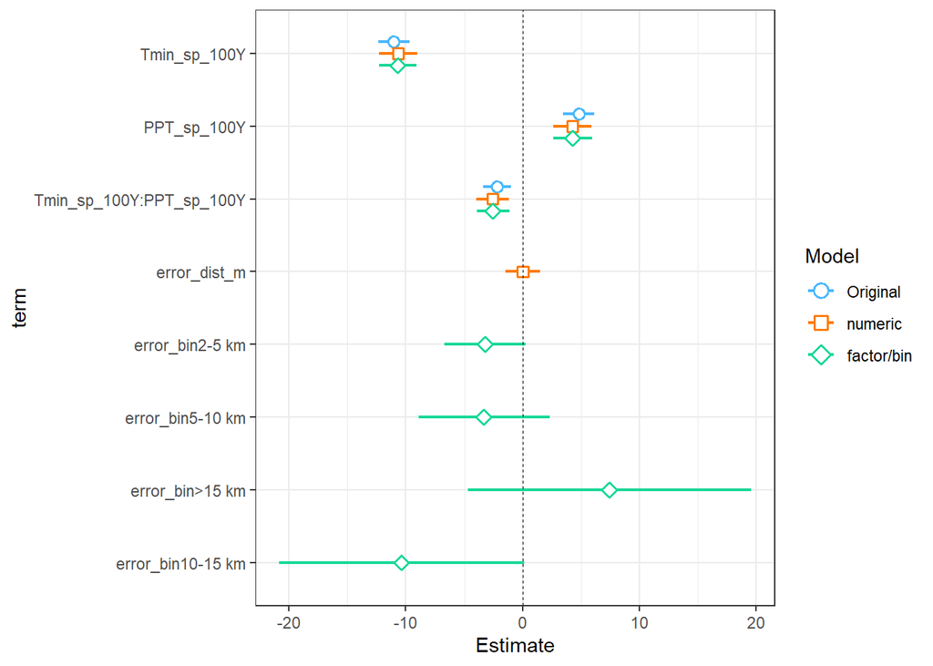

```r
plot_summs(Sp100Y_lm1i, Sp100Y_lm3ai, Sp100Y_lm3bi, model.names = c("Original", "numeric", "factor/bin"), scale = TRUE) + theme_bw()
```

```r
#With more covariates
Sp100Y_lm4a <- lm(DOY ~ Tmin_sp_100Y + PPT_sp_100Y + elev_m + long + year + error_dist_m, data = nemo_df2)
Sp100Y_lm4b <- lm(DOY ~ Tmin_sp_100Y + PPT_sp_100Y + elev_m + long + year + error_bin, data = nemo_df2)

summary(Sp100Y_lm4a)
```

```
##
## Call:
## lm(formula = DOY ~ Tmin_sp_100Y + PPT_sp_100Y + elev_m + long +
##     year + error_dist_m, data = nemo_df2)
##
## Residuals:
##     Min      1Q  Median      3Q     Max
## -81.683 -14.375  -0.922  14.751 150.709
##
## Coefficients:
##                Estimate Std. Error t value Pr(>|t|)
## (Intercept)   3.140e+02  7.116e+01   4.413 1.12e-05 ***
## Tmin_sp_100Y -2.037e+00  5.198e-01  -3.918 9.45e-05 ***
## PPT_sp_100Y   1.518e+01  1.915e+00   7.926 5.29e-15 ***
## elev_m        1.872e-02  2.631e-03   7.117 1.93e-12 ***
## long          1.348e+00  4.718e-01   2.856  0.00436 **
## year         -6.418e-02  2.665e-02  -2.408  0.01620 *
## error_dist_m  2.422e-05  1.497e-04   0.162  0.87153
## ---
## Signif. codes:  0 '***' 0.001 '**' 0.01 '*' 0.05 '.' 0.1 ' ' 1
##
## Residual standard error: 24.33 on 1159 degrees of freedom
##   (511 observations deleted due to missingness)
## Multiple R-squared:  0.3002, Adjusted R-squared:  0.2966
## F-statistic: 82.85 on 6 and 1159 DF,  p-value: < 2.2e-16
```

```r
summary(Sp100Y_lm4b)
```

```
##
## Call:
## lm(formula = DOY ~ Tmin_sp_100Y + PPT_sp_100Y + elev_m + long +
##     year + error_bin, data = nemo_df2)
##
## Residuals:
##     Min      1Q  Median      3Q     Max
## -82.485 -14.413  -0.484  15.090 149.604
##
## Coefficients:
##                     Estimate Std. Error t value Pr(>|t|)
## (Intercept)       354.205606  72.411938   4.892 1.14e-06 ***
## Tmin_sp_100Y       -2.135300   0.521985  -4.091 4.60e-05 ***
## PPT_sp_100Y        15.007056   1.903303   7.885 7.25e-15 ***
## elev_m              0.018384   0.002635   6.976 5.09e-12 ***
## long                1.317705   0.471215   2.796  0.00525 **
## year               -0.085015   0.027582  -3.082  0.00210 **
## error_bin2-5 km    -3.964147   1.749570  -2.266  0.02365 *
## error_bin5-10 km   -3.034099   2.774255  -1.094  0.27433
## error_bin>15 km     4.571666   5.850097   0.781  0.43469
## error_bin10-15 km  -8.523627   5.090168  -1.675  0.09430 .
## ---
## Signif. codes:  0 '***' 0.001 '**' 0.01 '*' 0.05 '.' 0.1 ' ' 1
##
## Residual standard error: 24.27 on 1156 degrees of freedom
##   (511 observations deleted due to missingness)
## Multiple R-squared:  0.3053, Adjusted R-squared:  0.2999
## F-statistic: 56.46 on 9 and 1156 DF,  p-value: < 2.2e-16
```

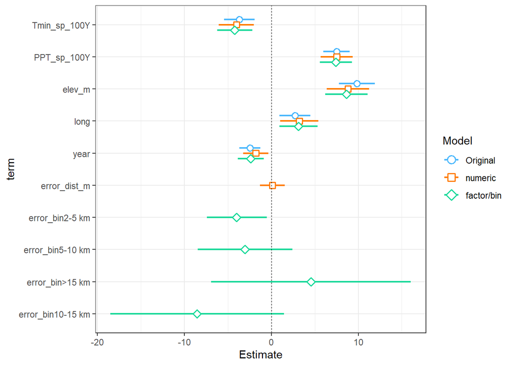

```r
plot_summs(Sp100Y_lm2, Sp100Y_lm4a, Sp100Y_lm4b, model.names = c("Original", "numeric", "factor/bin"), scale = TRUE) + theme_bw()
```

```r
#AIC Comparison - Spring
AIC(Sp100Y_lm1, Sp100Y_lm3a, Sp100Y_lm3b, Sp100Y_lm1i, Sp100Y_lm3ai, Sp100Y_lm3bi, Sp100Y_lm2, Sp100Y_lm4a, Sp100Y_lm4b)
```

```
##              df      AIC
## Sp100Y_lm1    4 15693.55
## Sp100Y_lm3a   5 10910.59
## Sp100Y_lm3b   8 10907.54
## Sp100Y_lm1i   5 15682.33
## Sp100Y_lm3ai  6 10900.03
## Sp100Y_lm3bi  9 10896.98
## Sp100Y_lm2    7 15486.60
## Sp100Y_lm4a   8 10760.72
## Sp100Y_lm4b  11 10758.08
```

At a glance, $R^2$ values do not seem to be significantly improved. However, among models with error as a covariate, the factor error_bin provides a higher $R^2$ (Though estimate standard errors are huge). There appears to be no significant change in parameter estimates, similar to the results of subsetting models by different error bins.

Is there any benefit to including error distance as a covariate in these models? Possibly in the case of milking higher $R^2$ values. See Excel sheet of model outputs for comparison. In the case of model selection via AIC, models with the `error_bin` factor had lower AIC values (lower than models without any error covariate).

In models with `error_bin`, the 2-5 km bin had, on multiple occasions, a significant effect on DOY. (Note: Double check on whether to use `options(contrasts = c("contr.sum", "contr.poly"))` - results in different estimates among factor levels) This is explored more below in the ANOVAs.

### Other variables as a response - checking for error distance~geography/climate trends/biases

#### ANOVAs and Linear Regressions

Are there differences in collected records lat/long, elevation, MAT/MAP (other climate) due to error distance (bins)?

Latitude & Longitude

```r
library(car)
###Fix contrasts?
#
#Log-transformation attempted on regression models

#Lat
#ANOVA
edbin1 <- lm(lat ~ error_bin, data = nemo_df2)
anova(edbin1)
```

```
## Analysis of Variance Table
##
## Response: lat
##             Df Sum Sq Mean Sq F value Pr(>F)
## error_bin    4   11.7  2.9181  0.5169 0.7233
## Residuals 1161 6554.3  5.6454
```

```r
#Regression
edbin1a <- lm(lat ~ error_dist_m, data = nemo_df2)
summary(edbin1a)
```

```
##
## Call:
## lm(formula = lat ~ error_dist_m, data = nemo_df2)
##
## Residuals:
##     Min      1Q  Median      3Q     Max
## -3.5211 -1.8813 -0.7269  2.0135  5.8753
##
## Coefficients:
##                Estimate Std. Error t value Pr(>|t|)
## (Intercept)   3.607e+01  7.894e-02 456.944   <2e-16 ***
## error_dist_m -1.054e-05  1.420e-05  -0.742    0.458
## ---
## Signif. codes:  0 '***' 0.001 '**' 0.01 '*' 0.05 '.' 0.1 ' ' 1
##
## Residual standard error: 2.374 on 1164 degrees of freedom
##   (511 observations deleted due to missingness)
## Multiple R-squared:  0.000473,   Adjusted R-squared:  -0.0003857
## F-statistic: 0.5508 on 1 and 1164 DF,  p-value: 0.4581
```

```r
#Long
#ANOVA
edbin2 <- lm(long ~ error_bin, data = nemo_df2)
anova(edbin2)
```

```
## Analysis of Variance Table
##
## Response: long
##             Df Sum Sq Mean Sq F value Pr(>F)
## error_bin    4   15.7  3.9349  0.6919 0.5976
## Residuals 1161 6603.2  5.6875
```

```r
#Regression
edbin2a <- lm(long ~ error_dist_m, data = nemo_df2)
summary(edbin2a)
```

```
##
## Call:
## lm(formula = long ~ error_dist_m, data = nemo_df2)
##
## Residuals:
##     Min      1Q  Median      3Q     Max
## -4.4638 -2.3215  0.0773  2.2496  4.3017
##
## Coefficients:
##                Estimate Std. Error   t value Pr(>|t|)
## (Intercept)  -1.199e+02  7.920e-02 -1513.421   <2e-16 ***
## error_dist_m  2.073e-05  1.425e-05     1.455    0.146
## ---
## Signif. codes:  0 '***' 0.001 '**' 0.01 '*' 0.05 '.' 0.1 ' ' 1
##
## Residual standard error: 2.382 on 1164 degrees of freedom
##   (511 observations deleted due to missingness)
## Multiple R-squared:  0.001815,   Adjusted R-squared:  0.0009575
## F-statistic: 2.117 on 1 and 1164 DF,  p-value: 0.146
```

Elevation

```r
#ANOVA
edbin3 <- lm(elev_m ~ error_bin, data = nemo_df2)
anova(edbin3)
```

```
## Analysis of Variance Table
##
## Response: elev_m
##             Df    Sum Sq Mean Sq F value  Pr(>F)
## error_bin    4   2126348  531587  2.4089 0.04765 *
## Residuals 1161 256206841  220678
## ---
## Signif. codes:  0 '***' 0.001 '**' 0.01 '*' 0.05 '.' 0.1 ' ' 1
```

```r
summary(edbin3)
```

```
##
## Call:
## lm(formula = elev_m ~ error_bin, data = nemo_df2)
##
## Residuals:
##    Min     1Q Median     3Q    Max
## -641.3 -382.3 -108.8  308.8 1490.8
##
## Coefficients:
##                   Estimate Std. Error t value Pr(>|t|)
## (Intercept)         632.76      17.23  36.716   <2e-16 ***
## error_bin2-5 km     -66.95      32.53  -2.058   0.0398 *
## error_bin5-10 km   -133.54      52.17  -2.559   0.0106 *
## error_bin>15 km      22.56     112.06   0.201   0.8405
## error_bin10-15 km    16.45      97.43   0.169   0.8660
## ---
## Signif. codes:  0 '***' 0.001 '**' 0.01 '*' 0.05 '.' 0.1 ' ' 1
##
## Residual standard error: 469.8 on 1161 degrees of freedom
##   (511 observations deleted due to missingness)
## Multiple R-squared:  0.008231,   Adjusted R-squared:  0.004814
## F-statistic: 2.409 on 4 and 1161 DF,  p-value: 0.04765
```

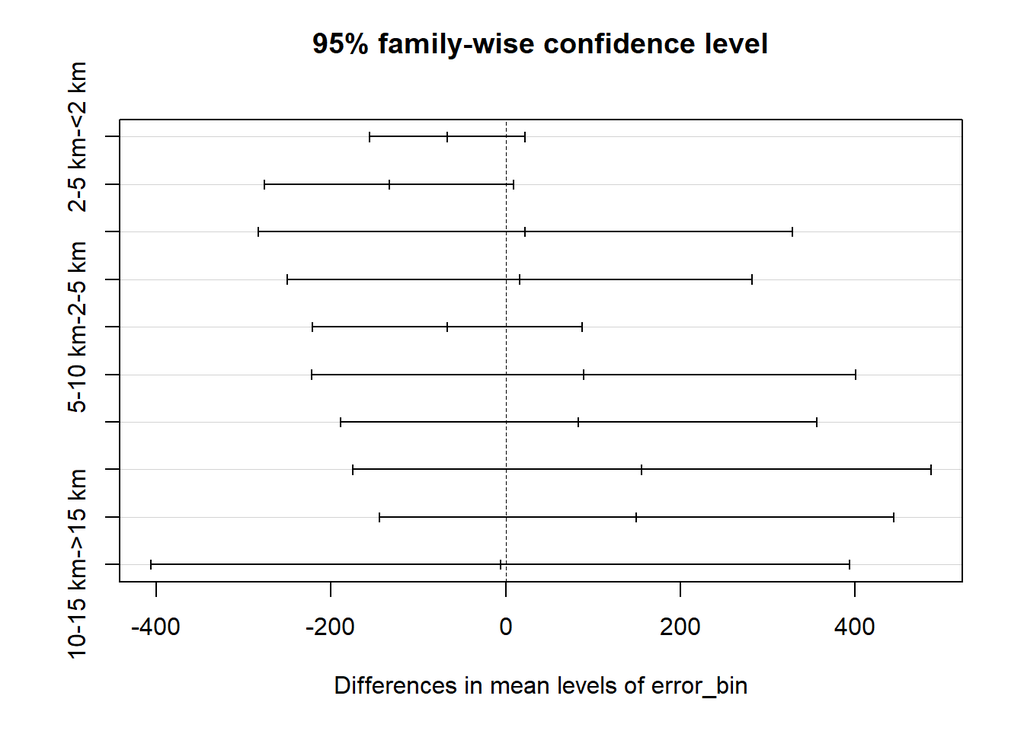

```r
#Elevation not quite normally distributed - what to do? #Maybe a sqrt transformation? or glm? Or leave as is

#plots
plot(TukeyHSD(aov(edbin3)))
```

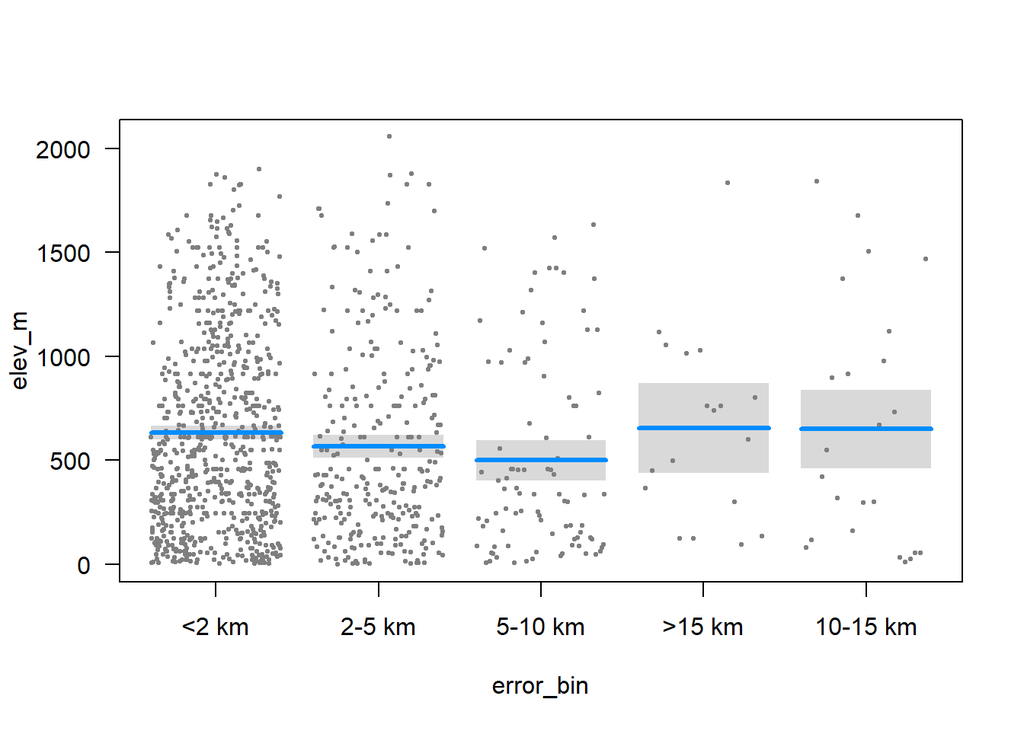

```r
visreg(edbin3)
```

```r
#ggplot(data = nemo_df2, aes(x = error_bin, y = elev_m)) +
#  geom_boxplot()



#Regression
edbin3a <- lm(elev_m ~ log(error_dist_m), data = nemo_df2)
summary(edbin3a)
```

```
##
## Call:
## lm(formula = elev_m ~ log(error_dist_m), data = nemo_df2)
##
## Residuals:
##    Min     1Q Median     3Q    Max
## -651.6 -381.0 -124.3  320.5 1467.5
##
## Coefficients:
##                   Estimate Std. Error t value Pr(>|t|)
## (Intercept)         760.68      80.69   9.428   <2e-16 ***
## log(error_dist_m)   -21.50      11.08  -1.941   0.0525 .
## ---
## Signif. codes:  0 '***' 0.001 '**' 0.01 '*' 0.05 '.' 0.1 ' ' 1
##
## Residual standard error: 470.3 on 1164 degrees of freedom
##   (511 observations deleted due to missingness)
## Multiple R-squared:  0.003226,   Adjusted R-squared:  0.00237
## F-statistic: 3.767 on 1 and 1164 DF,  p-value: 0.0525
```

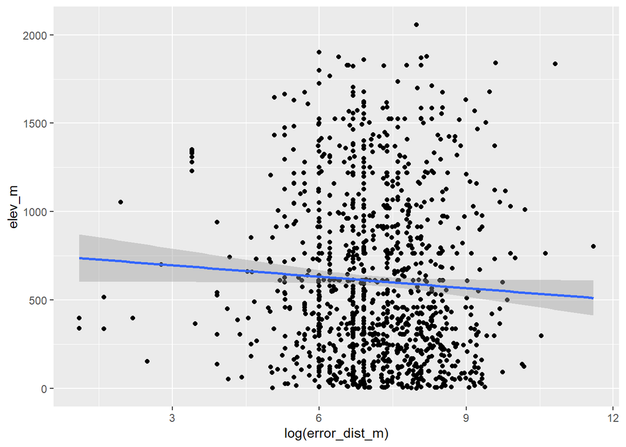

```r
#marginally significant with log()

ggplot(data = nemo_df2, aes(x = log(error_dist_m), y = elev_m)) +
  geom_point() +
  geom_smooth(method = 'lm')
```

MAT

```r
#ANOVA
edbin4 <- lm(MAT_100Y ~ error_bin, data = nemo_df2)
anova(edbin4)
```

```
## Analysis of Variance Table
##
## Response: MAT_100Y
##             Df Sum Sq Mean Sq F value  Pr(>F)
## error_bin    4   35.0  8.7549  2.7984 0.02494 *
## Residuals 1161 3632.3  3.1286
## ---
## Signif. codes:  0 '***' 0.001 '**' 0.01 '*' 0.05 '.' 0.1 ' ' 1
```

```r
summary(edbin4)
```

```
##
## Call:
## lm(formula = MAT_100Y ~ error_bin, data = nemo_df2)
##
## Residuals:
##     Min      1Q  Median      3Q     Max
## -6.7034 -1.0676  0.0225  1.3324  4.4633
##
## Coefficients:
##                   Estimate Std. Error t value Pr(>|t|)
## (Intercept)       14.80264    0.06489 228.117   <2e-16 ***
## error_bin2-5 km   -0.01123    0.12247  -0.092   0.9269
## error_bin5-10 km   0.21178    0.19645   1.078   0.2812
## error_bin>15 km    0.79419    0.42193   1.882   0.0600 .
## error_bin10-15 km -0.90397    0.36684  -2.464   0.0139 *
## ---
## Signif. codes:  0 '***' 0.001 '**' 0.01 '*' 0.05 '.' 0.1 ' ' 1
##
## Residual standard error: 1.769 on 1161 degrees of freedom
##   (511 observations deleted due to missingness)
## Multiple R-squared:  0.009549,   Adjusted R-squared:  0.006137
## F-statistic: 2.798 on 4 and 1161 DF,  p-value: 0.02494
```

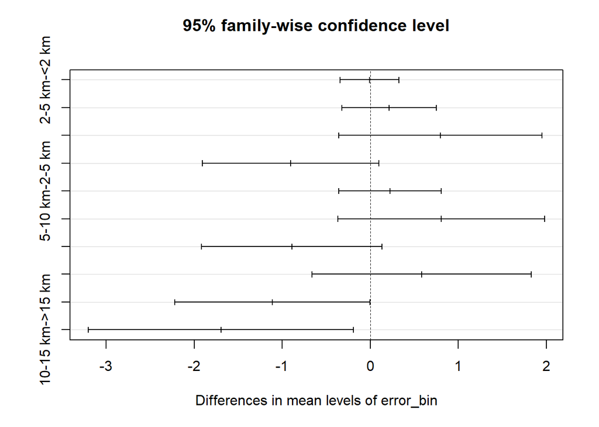

```r
plot(TukeyHSD(aov(edbin4)))
```

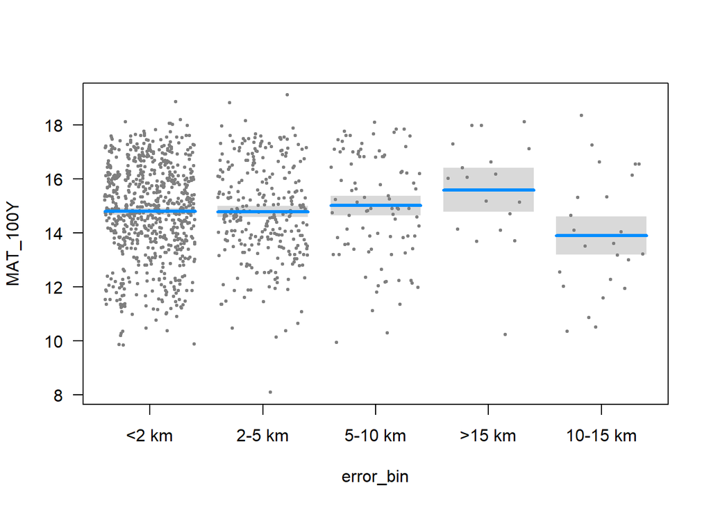

```r
#Diff b/w 10.15-15 km and 10.15-5-10 km
#Differences may not be significant from 0 in their effect ?

visreg(edbin4)
```

```r
#No discernible trend


#Regression
edbin4a <- lm(MAT_100Y ~ error_dist_m, data = nemo_df2)
summary(edbin4a) #ns #log trnsfrm no effect
```

```
##
## Call:
## lm(formula = MAT_100Y ~ error_dist_m, data = nemo_df2)
##
## Residuals:
##    Min     1Q Median     3Q    Max
## -6.726 -1.056  0.037  1.360  4.292
##
## Coefficients:
##               Estimate Std. Error t value Pr(>|t|)
## (Intercept)  1.478e+01  5.897e-02 250.574   <2e-16 ***
## error_dist_m 1.297e-05  1.061e-05   1.223    0.222
## ---
## Signif. codes:  0 '***' 0.001 '**' 0.01 '*' 0.05 '.' 0.1 ' ' 1
##
## Residual standard error: 1.774 on 1164 degrees of freedom
##   (511 observations deleted due to missingness)
## Multiple R-squared:  0.001283,   Adjusted R-squared:  0.0004252
## F-statistic: 1.496 on 1 and 1164 DF,  p-value: 0.2216
```

MAP

```r
#
#MAP
edbin5 <- lm(MAP_100Y ~ error_bin, data = nemo_df2)
anova(edbin5)
```

```
## Analysis of Variance Table
##
## Response: MAP_100Y
##             Df Sum Sq Mean Sq F value Pr(>F)
## error_bin    4   1.78 0.44442  1.6279 0.1649
## Residuals 1161 316.97 0.27301
```

```r
summary(edbin5)
```

```
##
## Call:
## lm(formula = MAP_100Y ~ error_bin, data = nemo_df2)
##
## Residuals:
##      Min       1Q   Median       3Q      Max
## -1.40640 -0.32315 -0.00249  0.31848  1.62428
##
## Coefficients:
##                   Estimate Std. Error t value Pr(>|t|)
## (Intercept)        6.42313    0.01917 335.081   <2e-16 ***
## error_bin2-5 km   -0.02133    0.03618  -0.589   0.5557
## error_bin5-10 km  -0.03063    0.05803  -0.528   0.5978
## error_bin>15 km   -0.30937    0.12464  -2.482   0.0132 *
## error_bin10-15 km -0.04388    0.10836  -0.405   0.6856
## ---
## Signif. codes:  0 '***' 0.001 '**' 0.01 '*' 0.05 '.' 0.1 ' ' 1
##
## Residual standard error: 0.5225 on 1161 degrees of freedom
##   (511 observations deleted due to missingness)
## Multiple R-squared:  0.005577,   Adjusted R-squared:  0.002151
## F-statistic: 1.628 on 4 and 1161 DF,  p-value: 0.1649
```

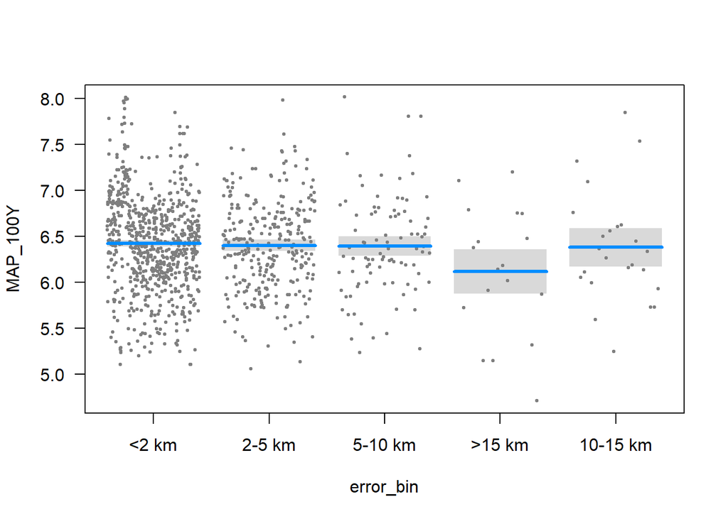

```r
visreg(edbin5)
```

```r
#Regression
edbin5a <- lm(MAP_100Y ~ error_dist_m, data = nemo_df2)
summary(edbin5a) #unusual - very significant
```

```
##
## Call:
## lm(formula = MAP_100Y ~ error_dist_m, data = nemo_df2)
##
## Residuals:
##      Min       1Q   Median       3Q      Max
## -1.35231 -0.32778 -0.00661  0.31029  1.65532
##
## Coefficients:
##                Estimate Std. Error t value Pr(>|t|)
## (Intercept)   6.439e+00  1.730e-02 372.080  < 2e-16 ***
## error_dist_m -1.094e-05  3.113e-06  -3.516 0.000456 ***
## ---
## Signif. codes:  0 '***' 0.001 '**' 0.01 '*' 0.05 '.' 0.1 ' ' 1
##
## Residual standard error: 0.5205 on 1164 degrees of freedom
##   (511 observations deleted due to missingness)
## Multiple R-squared:  0.01051,    Adjusted R-squared:  0.009656
## F-statistic: 12.36 on 1 and 1164 DF,  p-value: 0.0004557
```

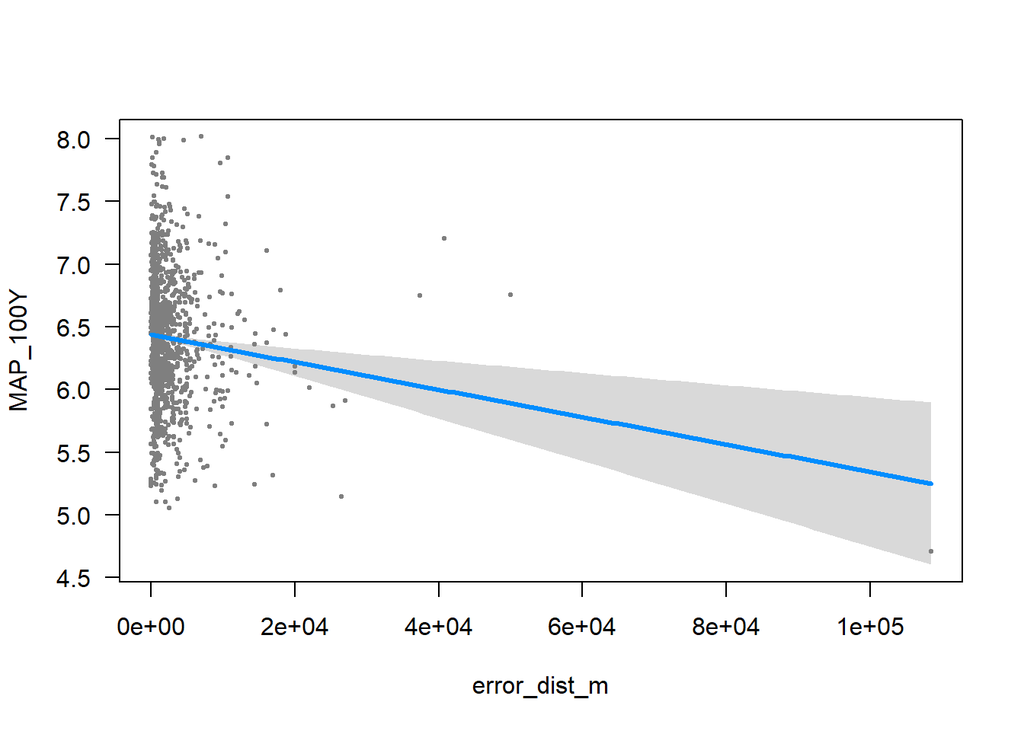

```r
visreg(edbin5a)
```

```r
edbin5b <- lm(MAP_100Y ~ log(error_dist_m), data = nemo_df2)
summary(edbin5b) #significance lost with log transformation - likely noise?
```

```
##
## Call:
## lm(formula = MAP_100Y ~ log(error_dist_m), data = nemo_df2)
##
## Residuals:
##      Min       1Q   Median       3Q      Max
## -1.60077 -0.32769 -0.00802  0.31318  1.64575
##
## Coefficients:
##                   Estimate Std. Error t value Pr(>|t|)
## (Intercept)        6.57485    0.08963  73.352   <2e-16 ***
## log(error_dist_m) -0.02300    0.01231  -1.869   0.0618 .
## ---
## Signif. codes:  0 '***' 0.001 '**' 0.01 '*' 0.05 '.' 0.1 ' ' 1
##
## Residual standard error: 0.5225 on 1164 degrees of freedom
##   (511 observations deleted due to missingness)
## Multiple R-squared:  0.002993,   Adjusted R-squared:  0.002136
## F-statistic: 3.494 on 1 and 1164 DF,  p-value: 0.06183
```

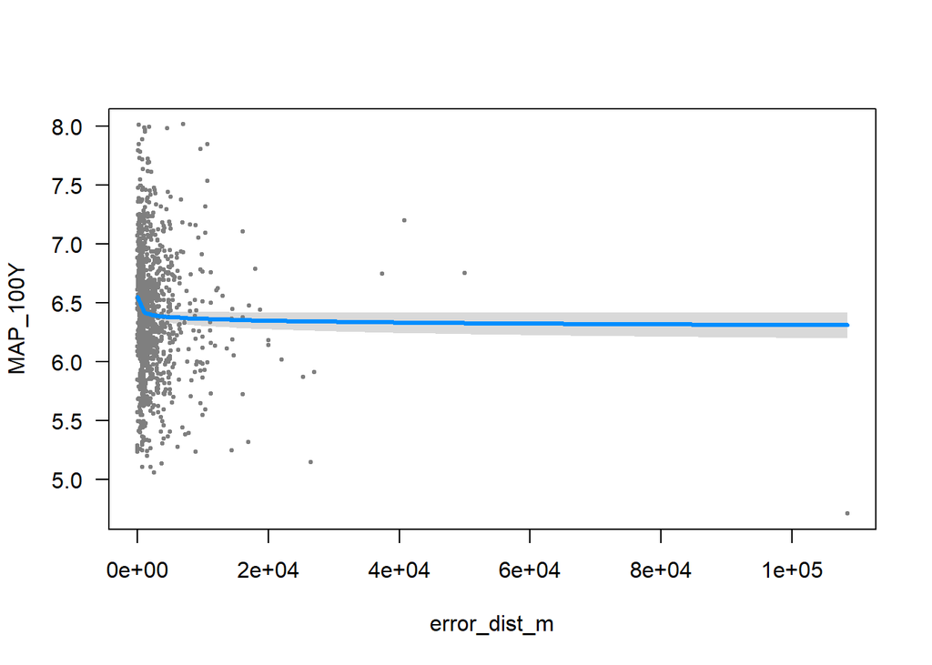

```r
visreg(edbin5b)
```

### Investigating the effect of manually georeferenced specimens on the relationship b/w DOY and climate variables

#### Subsetting models

```r
#USE pre 1901 records for this? or no...
#Records we georeferenced:
nemo_geor <- nemo_df2 %>%
  filter(!is.na(georef_by)) #N = 438 obs

nemo_ngeo <- nemo_df2 %>%
  filter(is.na(georef_by)) #records that we did not georeference (N = 1239)
```

MAT & MAP

```r
#Our georeferenced records relative to all records
#Just climate predictors
M100Y_lmg1 <- lm(DOY ~ MAT_100Y + MAP_100Y, data = nemo_geor)
summary(M100Y_lmg1)
```

```
##
## Call:
## lm(formula = DOY ~ MAT_100Y + MAP_100Y, data = nemo_geor)
##
## Residuals:
##    Min     1Q Median     3Q    Max
## -74.84 -15.92  -0.91  15.87  91.38
##
## Coefficients:
##             Estimate Std. Error t value Pr(>|t|)
## (Intercept)  85.7119    32.2308   2.659  0.00812 **
## MAT_100Y     -2.9327     0.9587  -3.059  0.00236 **
## MAP_100Y      8.8844     3.2215   2.758  0.00606 **
## ---
## Signif. codes:  0 '***' 0.001 '**' 0.01 '*' 0.05 '.' 0.1 ' ' 1
##
## Residual standard error: 26.78 on 435 degrees of freedom
## Multiple R-squared:  0.1085, Adjusted R-squared:  0.1044
## F-statistic: 26.48 on 2 and 435 DF,  p-value: 1.41e-11
```

```r
#Other predictors
M100Y_lmg2 <- lm(DOY ~ MAT_100Y + MAP_100Y + elev_m + long + year, data = nemo_geor)
summary(M100Y_lmg2)
```

```
##
## Call:
## lm(formula = DOY ~ MAT_100Y + MAP_100Y + elev_m + long + year,
##     data = nemo_geor)
##
## Residuals:
##    Min     1Q Median     3Q    Max
## -71.04 -14.71   0.04  15.85  68.63
##
## Coefficients:
##               Estimate Std. Error t value Pr(>|t|)
## (Intercept) 481.063901 149.480726   3.218  0.00139 **
## MAT_100Y     -2.141335   1.092034  -1.961  0.05054 .
## MAP_100Y     14.777197   3.648697   4.050 6.07e-05 ***
## elev_m        0.017604   0.004235   4.157 3.90e-05 ***
## long          2.312360   1.080867   2.139  0.03297 *
## year         -0.089777   0.046125  -1.946  0.05226 .
## ---
## Signif. codes:  0 '***' 0.001 '**' 0.01 '*' 0.05 '.' 0.1 ' ' 1
##
## Residual standard error: 24.74 on 432 degrees of freedom
## Multiple R-squared:  0.2443, Adjusted R-squared:  0.2356
## F-statistic: 27.94 on 5 and 432 DF,  p-value: < 2.2e-16
```

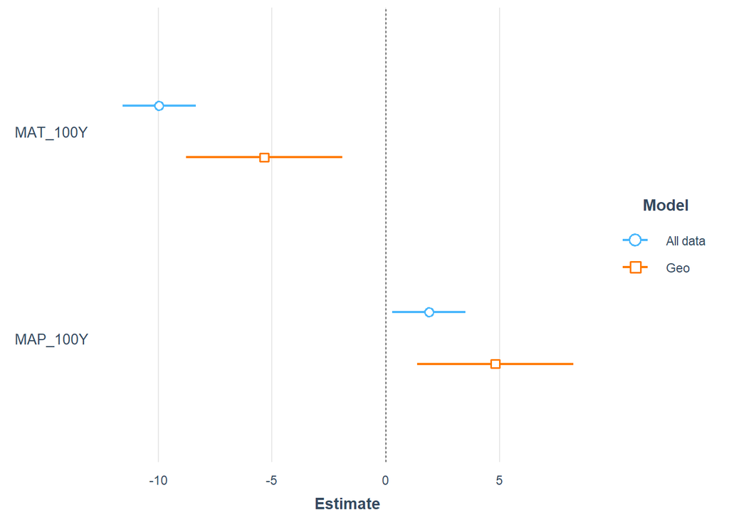

```r
plot_summs(M100Y_lm1, M100Y_lmg1, model.names = c("All data", "Geo"), scale = TRUE)
```

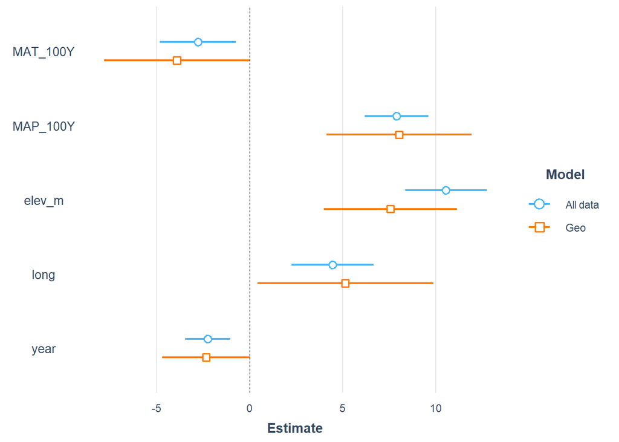

```r
plot_summs(M100Y_lm2, M100Y_lmg2, model.names = c("All data", "Geo"), scale = TRUE)
```

From these averages it’s clear that subsetting by specimens we georeferenced increases variation in the parameter estimate, as did subsetting by smaller error distances above. In the model with climate-only predictors, our georeferenced specimens alone may be underestimating the effect of MAT_100Y on DOY…